# PWM-scan for motifs

Melanie (1028-02098-001-001)

March 23, 2026

# Introduction

Here, we want to investigate, upon PWM scanning based on the PWM representation of the TF-MoDISco seqlets, whether our CWM scanning approach returns high-quality motifs. We also want to check whether the PWM-scanned false positive motifs are all poor matches (i.e. is PWM scanning totally fine at high affinities?) and whether our hit mapping thresholds appropriately find sequences of high contribution.

# Computational Setup

```r
#Standard packages
library(rtracklayer) ; library(GenomicRanges); library(magrittr) ; library(Biostrings)
library(ggplot2) ; library(reshape2); library(plyranges); library(Rsamtools); library(parallel)
library(dplyr); library(data.table); library(patchwork); library(readr); library(testit)

#KNITR Options
setwd("/n/projects/mw2098/publications/2024_weilert_acc/code/2_analysis/")
figure_filepath<-"figures/7_scan_pwms"
options(knitr.figure_dir=figure_filepath, java.parameters = "- Xmx6g")

#Lab sources
source("scripts/r/granges_common.r")
source("scripts/r/metapeak_common.r")
source("scripts/r/knitr_common.r")
source("scripts/r/caching.r")
source("scripts/r/metapeak_functions.r")
source("scripts/r/motif_functions.r")

#Specific sources
library(BSgenome.Mmusculus.UCSC.mm10)
library(TxDb.Mmusculus.UCSC.mm10.knownGene)
library(org.Mm.eg.db)
library(ggseqlogo)
source("scripts/r/motif_functions.r")
library(rhdf5)

#Pre-existing variables
threads <- 5
dir.create('memesuite/seqs', recursive = T, showWarnings = F)
bsgenome<-BSgenome.Mmusculus.UCSC.mm10
txdb<-TxDb.Mmusculus.UCSC.mm10.knownGene

motif.path<-'tsv/mapped_motifs/all_instances_curated_1based.tsv.gz'
regions.path<-'tsv/mapped_motifs/all_islands_curated_1based_w_experimental_data.tsv.gz'
peaks.path<-'bed/bpreveal/bpnet_osknz_fold1_all.bed'

motif_to_task.list<-list('Oct4-Sox2' = 'oct4', 'Sox2' = 'sox2', 'Klf4' = 'klf4', 'Zic3' = 'zic3', 'Nanog' = 'nanog')
output_length <- 1000
```

Here, we chose not to validate with Oct only motifs due to (1) it not having much to do with accessibility, (2) poorly bound and unreliable, (3) the fact that the mapping primarily happens on ERVs so PWM-scanning will be intrinsically off. Not a helpful or insightful analysis.

# Define plotting functions

```r
plot_standard_heatmap_local<-function(regions.gr, sample, title="Heatmap of ChIP-seq Signals", order="sum", output_file_name=NA, reduce=F,
                             upstream=50, downstream=50, normalize = T, color_vec =  c("white", '#fff5f0', '#fee0d2','#fcbba1','#fc9272','#fb6a4a','#ef3b2c','#cb181d','#a50f15'),
                             removal_threshold=.5, normalize_threshold=0.99, reverse=F, return_only_df = F, swap_na_with_zero = F){
  library(testit)
  testit::assert('Reducing the GRanges and applying a custom ordering is not compatible settings.',
                 ifelse(reduce, ifelse((order=='sum' | order=='clustering'), TRUE, FALSE), TRUE))

  if(reverse){strand(regions.gr) <- ifelse(strand(regions.gr) == '+', '-', '+')}
  if(reduce){regions.gr<-GenomicRanges::reduce(regions.gr)}
  print(length(regions.gr))

  #Get signals across regions
  mat<-standard_metapeak_matrix(regions.gr = resize(regions.gr, 1, "start"), sample=sample, upstream=upstream, downstream=downstream)


  #Order region rows
  if(order=="clustering"){
    order_of_rows<-hclust(d = dist(mat))$order
  }
  else if (order=="sum"){
    nrows<-length(mat[,1])
    sum_by_rows_vec<-apply(mat, 1, sum)
    order_of_rows<-order(sum_by_rows_vec, decreasing=F)
  }
  else{order_of_rows<-1:length(regions.gr)}

  rownames(mat)<-1:nrow(mat)
  mat<-mat[order_of_rows, ]

  #Normalize matrix
  if(normalize){
    norm_mat_matrix<-normalize_standard_matrix(mat, removal_threshold =  removal_threshold, normalize_threshold = normalize_threshold)
    fill_axis = 'norm. signal'
  } else {
    norm_mat_matrix<-mat
    fill_axis = 'signal'
  }

  #Format matrix
  mat_final_df<-format_standard_matrix_for_heatmap(matrix = norm_mat_matrix, downstream = downstream, upstream = upstream, swap_na_with_zero = swap_na_with_zero)

  if(return_only_df){
    return(mat_final_df)
  }
  else{
    #Plot matrix
    g<-ggplot()+
      ggrastr::geom_tile_rast(data=mat_final_df, aes(x=position, y=region, fill=signal))+
      ggtitle(title, subtitle = length(regions.gr))+
      scale_x_continuous("Position (bp)", expand = c(0, 0))+
      scale_y_reverse("Regions", expand = c(0, 0))+
      scale_fill_gradientn(colors = color_vec, name = fill_axis) +
      # scale_fill_gradient2(low="#08306b", mid="white", high="#67000d")+
      theme_classic()+
      theme(legend.position="bottom", panel.grid = element_blank(), panel.border = element_blank())

    if(!is.na(output_file_name)){ggsave(filename = paste(getwd(), output_file_name, sep="/"), plot = g, width = 12, height=12)}
    return(g)
  }
}
```

# Import motifs

```r
motifs.gr<-readr::read_tsv(motif.path) %>%
  makeGRangesFromDataFrame(keep.extra.columns = T, starts.in.df.are.0based = F)
regions.gr<-readr::read_tsv(regions.path) %>%
  makeGRangesFromDataFrame(keep.extra.columns = T, starts.in.df.are.0based = F)
```

# Extract seqlet logos

Define TF mapped motifs

```r
tf_seqlet_ids.df<-data.frame(
      metacluster_name = 'pos_patterns', #Need this if you also have negative patterns
      pattern_name = c('pattern_0', 'pattern_0', 'pattern_0', 'pattern_1', 'pattern_0'),
      motif = c('Klf4', 'Sox2', 'Oct4-Sox2', 'Nanog', 'Zic3'),
      oriented_strand = c('-', '+' , '+', '-', '+'),
      task = c('klf4', 'sox2', 'oct4', 'nanog', 'zic3')
)

acc_seqlet_ids.df<-data.frame(
      metacluster_name = 'pos_patterns', # Need this if you also have negative patterns
      pattern_name = c('pattern_0', 'pattern_1', 'pattern_2', 'pattern_5'),
      motif = c('Klf4', 'Oct4-Sox2', 'Sox2', 'Zic3'),
      oriented_strand = c('+', '-' , '-', '-')
)
```

Define 0-based seqlet-to-hit trimming alignment. This will be manually specified for simplicity from looking at coordinates at (`modiscolite/bpnet_osknz_fold1_oct4_counts/motifs.html`)

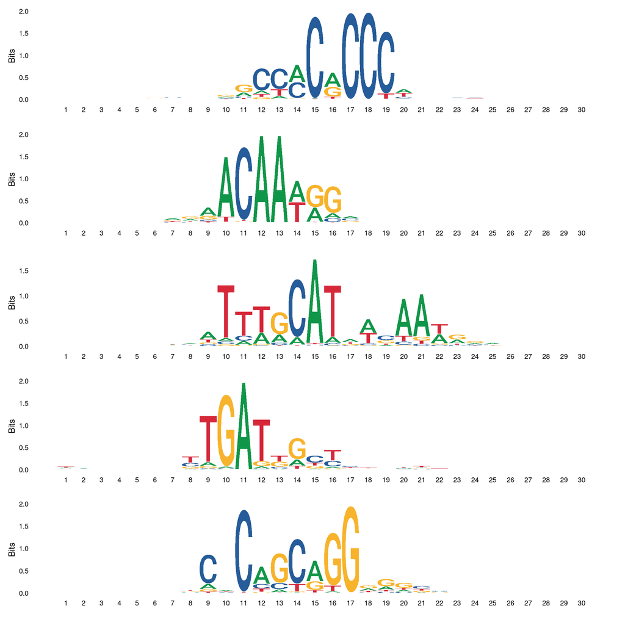

```r
lapply(1:nrow(tf_seqlet_ids.df), function(x){
  df<-tf_seqlet_ids.df[x,]
  plot<-readr::read_tsv(paste0('modiscolite/bpnet_osknz_fold1_', df$task, '_counts/seqlets.tsv')) %>%
    dplyr::filter(metacluster_name==df$metacluster_name, pattern_name == df$pattern_name) %>%
    .$sequence %>%
    ggseqlogo(.)
}) %>% wrap_plots(ncol = 1)
```

```r
motif_boundaries.list<-list('Oct4-Sox2' = c(9, 23),
                            'Sox2' = c(9, 17),
                            'Klf4'= c(10, 20),
                            'Zic3' = c(8, 18),
                            'Nanog'= c(8, 15))
```

Get IC logo.

```r
#Get seqlets
seqlets.df.list<-lapply(1:nrow(tf_seqlet_ids.df), function(x){
  df<-tf_seqlet_ids.df[x,]
  seqlets.df<-readr::read_tsv(paste0('modiscolite/bpnet_osknz_fold1_', df$task, '_counts/seqlets.tsv')) %>%
    dplyr::filter(metacluster_name==df$metacluster_name, pattern_name == df$pattern_name) %>%
    dplyr::mutate(sequence = stringr::str_sub(sequence, motif_boundaries.list[[df$motif]][1], motif_boundaries.list[[df$motif]][2]))

  #Account for strand
  if(df$oriented_strand == '+') {
    seqlets.df<-seqlets.df %>%
      dplyr::mutate(seq = sequence)
  } else {
    seqlets.df<-seqlets.df %>%
      dplyr::mutate(strand = ifelse(strand == '+', '-', '+'),
                    seq = as.character(reverseComplement(DNAStringSet(sequence))))
  }
  print(ggseqlogo(seqlets.df$seq))
  return(seqlets.df)
})
```

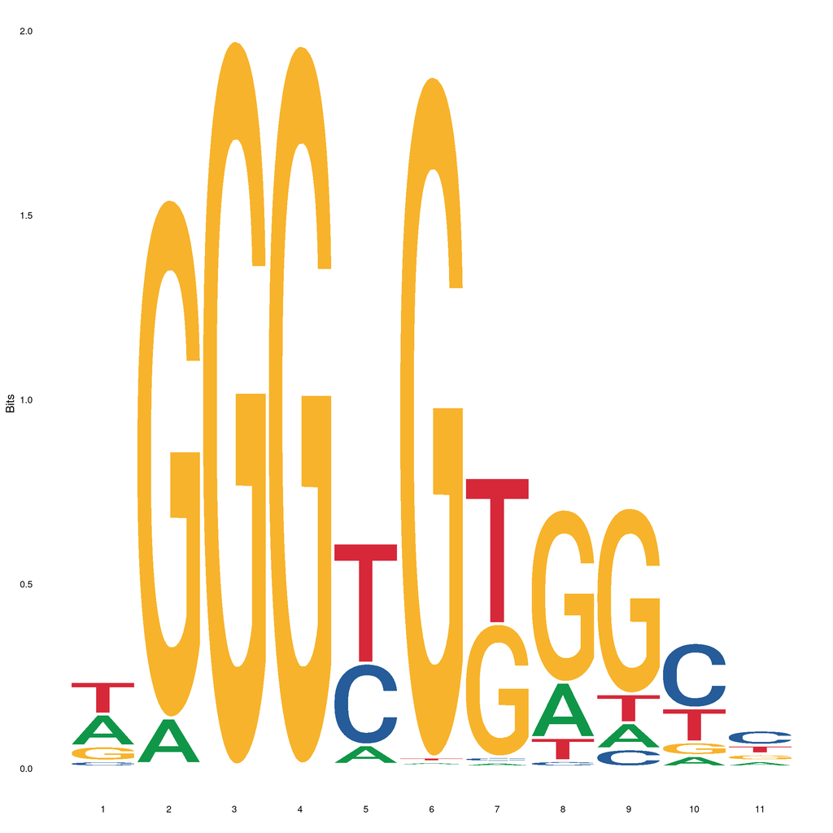

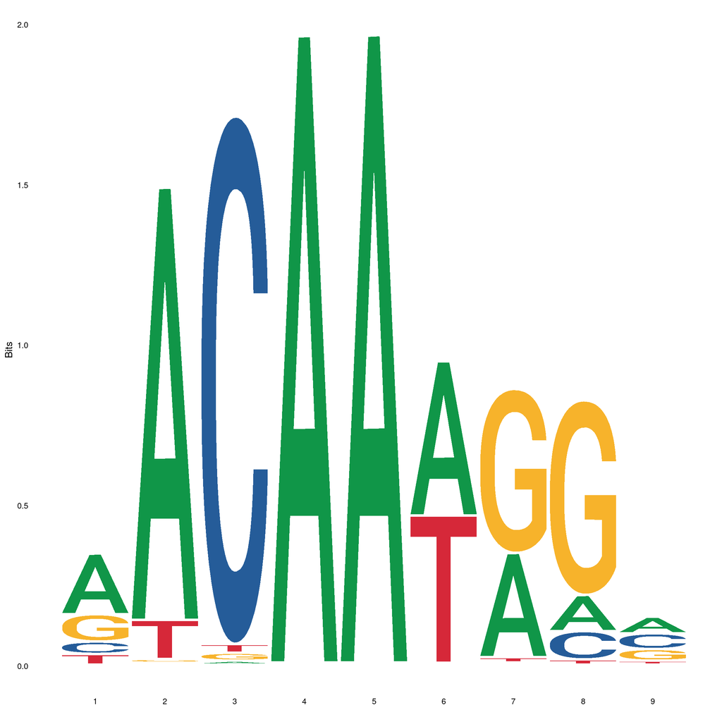

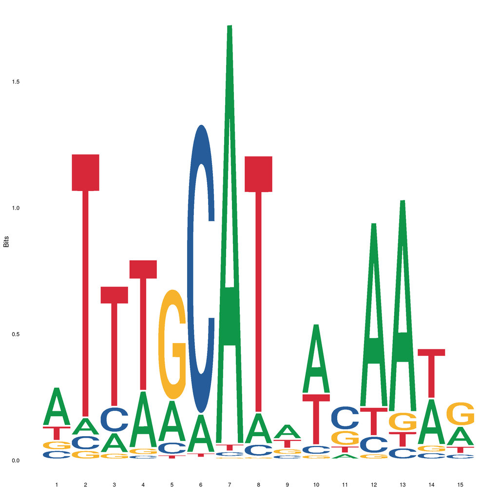

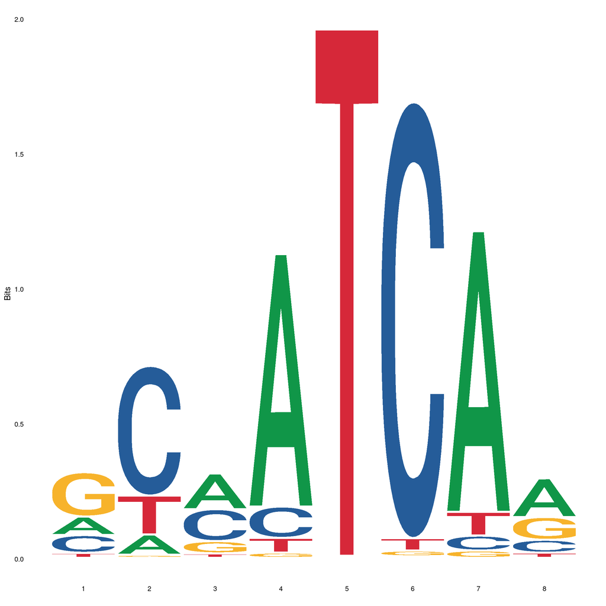

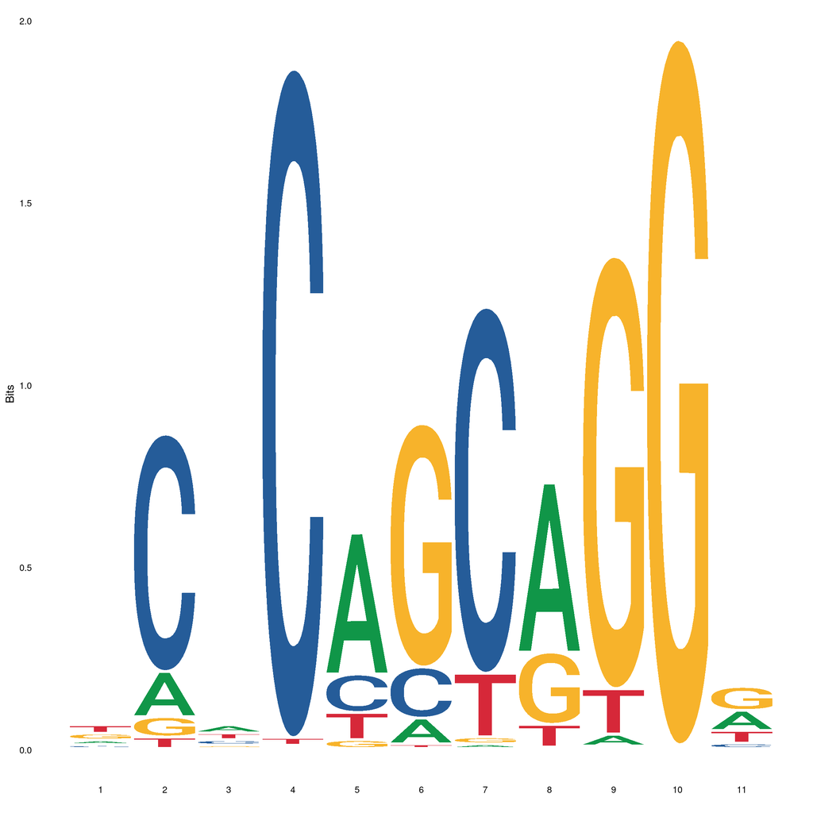

```r
names(seqlets.df.list)<-tf_seqlet_ids.df$motif

#Get IC content
ic.list<-lapply(tf_seqlet_ids.df$motif, function(x){
  seqs<-seqlets.df.list[[x]]$seq
  seq_ic<-ppm_to_ic(seq_to_ppm(seqs),  bg_freq = c(.3, .2, .2, .3))
  return(seq_ic)
})
names(ic.list)<-tf_seqlet_ids.df$motif

#Get logodds content
logodds.list<-lapply(tf_seqlet_ids.df$motif, function(x){
  seqs<-seqlets.df.list[[x]]$seq
  seq_logodds<-ppm_to_pwm(seq_to_ppm(seqs),  bg_freq = c(.3, .2, .2, .3))
  readr::write_lines(seqs, file = paste0('memesuite/seqs/', x, '.txt'))
  return(seq_logodds)
})
names(logodds.list)<-tf_seqlet_ids.df$motif

ic.list$`Oct4-Sox2`
```

```
##          [,1]     [,2]      [,3]    [,4]     [,5]     [,6]     [,7]     [,8]
## [1,] 0.451407 0.000000 0.0000000 0.00000 0.000000 0.000000 1.623253 0.000000
## [2,] 0.000000 0.000000 0.0000000 0.00000 0.000000 1.824597 0.000000 0.000000
## [3,] 0.000000 0.000000 0.0000000 0.00000 1.113113 0.000000 0.000000 0.000000
## [4,] 0.000000 1.314164 0.8454373 0.74226 0.000000 0.000000 0.000000 1.264602
##           [,9]     [,10]     [,11]    [,12]    [,13]     [,14]      [,15]
## [1,] 0.2130831 0.4007054 0.0000000 1.072534 1.182129 0.1978201 0.06467586
## [2,] 0.0000000 0.0000000 0.5437755 0.000000 0.000000 0.0000000 0.00000000
## [3,] 0.0000000 0.0000000 0.1554449 0.000000 0.000000 0.0000000 0.46364375
## [4,] 0.0000000 0.1296558 0.0000000 0.000000 0.000000 0.2673077 0.00000000
```

```r
logodds.list$`Oct4-Sox2`
```

```
##         [,1]      [,2]       [,3]        [,4]      [,5]      [,6]      [,7]
## A  0.8403699 -2.356701 -1.3520730 -0.07234567 -0.296325 -1.371613  1.683979
## C -0.6491471 -2.037743 -0.4240806 -3.16591194 -1.416813  2.111344 -4.009043
## G -0.6154771 -2.727907 -2.4240806 -2.48662206  1.705952 -5.246082 -5.053437
## T -0.5509369  1.523614  1.2144419  1.13028087 -3.405739 -4.360415 -4.089963
##        [,8]       [,9]      [,10]      [,11]     [,12]     [,13]      [,14]
## A -1.537212  0.5016631  0.7786089 -1.4289463  1.376737  1.446143  0.4745610
## C -2.272077 -0.6030507 -1.5050006  1.1909266 -1.428459 -2.139351 -1.6594033
## G -4.398085 -0.1967005 -2.5204969  0.5360267 -3.022218 -1.426998 -1.5599820
## T  1.495256 -0.1570039  0.3411684 -1.0792138 -1.297659 -2.256424  0.5913805
##        [,15]
## A  0.1891018
## C -1.0602157
## G  1.0894357
## T -1.1361646
```

# Impute Oct4/Sox2 affinity components from Oct4-Sox2 heterodimer motif

It could be useful to know “what is the individual sequence match of the Oct4 and Sox2 component of the Oct4-Sox2 motif”

```r
# os_seqlet.df<-seqlets.df.list$`Oct4-Sox2`
# os_motifs.gr<-motifs.gr %>% plyranges::filter(motif == 'Oct4-Sox2')
# ic<-ic.list[['Oct4-Sox2']]
# oct4_ic<-ic[, 1:8]
# sox2_ic<-ic[, 9:15]
#
# #Get match scores for each component
# oct4_seqlet_match_scores<-mclapply(os_seqlet.df$seq, function(y) get_sequence_ic(ic = oct4_ic, seq = stringr::str_sub(y, 1, 8)), mc.cores = 8) %>% unlist()
# sox2_seqlet_match_scores<-mclapply(os_seqlet.df$seq, function(y) get_sequence_ic(ic = sox2_ic, seq = stringr::str_sub(y, 9, 15)), mc.cores = 8) %>% unlist()
# os_motifs.gr$oct4_match_scores<-mclapply(os_motifs.gr$seq, function(y) get_sequence_ic(ic = oct4_ic, seq = stringr::str_sub(y, 1, 8)), mc.cores = 8) %>% unlist()
# os_motifs.gr$sox2_match_scores<-mclapply(os_motifs.gr$seq, function(y) get_sequence_ic(ic = sox2_ic, seq = stringr::str_sub(y, 9, 15)), mc.cores = 8) %>% unlist()
#
# #Get quantiles based on seqlet distributions
# oct4_match_score_dist<-ecdf(oct4_seqlet_match_scores)
# sox2_match_score_dist<-ecdf(sox2_seqlet_match_scores)
# os_motifs.gr$oct4_match_scores_q<-oct4_match_score_dist(os_motifs.gr$oct4_match_scores)
# os_motifs.gr$sox2_match_scores_q<-sox2_match_score_dist(os_motifs.gr$sox2_match_scores)
#
# #Export OS match scores based on mapped motifs
# os_motifs.gr %>%
#   as.data.frame %>%
#   dplyr::select(motif, seq, seq_match_quantile, oct4_match_scores_q, sox2_match_scores_q) %>%
#   dplyr::rename(oct4sox2_sequence_quantile = seq_match_quantile,
#                 oct4_sequence_quantile = oct4_match_scores_q,
#                 sox2_sequence_quantile = sox2_match_scores_q) %>%
#   readr::write_tsv(., 'tsv/mapped_motifs/Oct4Sox2_sequences_w_subcomponent_affinities.tsv.gz')
```

We analyzed this and found:

1. Higher Sox2 in OS affinity was associated with more pioneering
2. Higher Oct4 in OS affinity was associated with stronger residence time dip in accessibility profiles (Pampari 2025)

Could look more at this, but wasnt focus of paper.

# Convert sequences to MEME format

```bash
ml meme/5.5.3
sites2meme memesuite/seqs > memesuite/custom_meme.txt
```

# Run FIMO on .fa sequences

Export all regions to .fa file

```r
regions.gr<-rtracklayer::import('bed/mapped_motifs/all_islands_curated_0based_sized_to_input.bed')
regions.seq<-getSeq(bsgenome, regions.gr)
names(regions.seq)<-paste0(seqnames(regions.gr), ':', start(regions.gr), '-', end(regions.gr)) #FIMO works with 1-based coords
writeXStringSet(regions.seq, 'memesuite/all_islands_curated_seqs.fa')
```

Run FIMO

```r
cmds_all.vec<-c('#!bin/bash', 'module load meme',
                'fimo --oc memesuite --skip-matched-sequence --parse-genomic-coord --max-strand --thresh 0.001 --max-stored-scores 10000000 memesuite/custom_meme.txt memesuite/all_islands_curated_seqs.fa > memesuite/fimo_matches.tsv')
writeLines(cmds_all.vec, 'scripts/scan_pwms_using_fimo.sh')
```

Run the code.

# Calculate PWM match score for each motif set

Reimplement quantile measuring for PWM scanning scores. We will be calculating the PWM match scores again (represented as logodds and information content) because FIMO does some weird rounding to speed up calculations (https://groups.google.com/g/meme-suite/c/BXv4pRCacN8). This means that our CWM-mapped scores and our FIMO-mapped scores do not operate on the exact same math (even though they’re derived from the same logos).

```r
#Import PWM-matched motifs and assign information to them
pwm_matches.df<-readr::read_tsv('memesuite/fimo_matches.tsv')
pwm_matches.gr<-pwm_matches.df %>%
  makeGRangesFromDataFrame(keep.extra.columns = T, ignore.strand = F,
                           starts.in.df.are.0based = F, seqnames.field = 'sequence_name') %>%
  plyranges::mutate(seq = getSeq(bsgenome, ., as.character = T),
                    motif = motif_id)  %>%
  plyranges::filter(motif %in% tf_seqlet_ids.df$motif)

#Reimplement quantile measuring for PWM scanning scores.
all_motifs.list<-lapply(tf_seqlet_ids.df$motif, function(x){
  message(x)

  #Call each set of motifs
  seqlet.df<-seqlets.df.list[[x]]
  motif.gr<-motifs.gr %>% plyranges::filter(motif == x)
  pwm.gr<-pwm_matches.gr %>% plyranges::filter(motif == x) %>% unique()

  #Get log2-derived IC
  ic<-ic.list[[x]]
  pwm<-logodds.list[[x]]

  #Get PWM scores (information content)
  message('getting seqlets...')
  seqlet.df$ic_match_score<-mclapply(seqlet.df$seq, function(y) get_sequence_ic(ic = ic, seq = y), mc.cores = 8) %>% unlist()
  message('getting motifs...')
  motif.gr$ic_match_score<-mclapply(motif.gr$seq, function(y) get_sequence_ic(ic = ic, seq = y), mc.cores = 8) %>% unlist()
  message('getting pwms...')
  pwm.gr$ic_match_score<-mclapply(pwm.gr$seq, function(y) get_sequence_ic(ic = ic, seq = y), mc.cores = 8) %>% unlist()

  #Get PWM scores (logodds)
  message('getting seqlets...')
  seqlet.df$pwm_match_score<-mclapply(seqlet.df$seq, function(y) get_sequence_logodds(pwm = pwm, seq = y), mc.cores = 36) %>% unlist()
  message('getting motifs...')
  motif.gr$pwm_match_score<-mclapply(motif.gr$seq, function(y) get_sequence_logodds(pwm = pwm, seq = y), mc.cores = 36) %>% unlist()
  message('getting pwms...')
  pwm.gr$pwm_match_score<-mclapply(pwm.gr$seq, function(y) get_sequence_logodds(pwm = pwm, seq = y), mc.cores = 36) %>% unlist()

  #Get quantiles based on seqlet distributions
  ic_score_dist<-ecdf(seqlet.df$ic_match_score)
  match_score_dist<-ecdf(seqlet.df$pwm_match_score)

  seqlet.df$ic_match_score_q<-ic_score_dist(seqlet.df$ic_match_score)
  motif.gr$ic_match_score_q<-ic_score_dist(motif.gr$ic_match_score)
  pwm.gr$ic_match_score_q<-ic_score_dist(pwm.gr$ic_match_score)

  seqlet.df$pwm_match_score_q<-match_score_dist(seqlet.df$pwm_match_score)
  motif.gr$pwm_match_score_q<-match_score_dist(motif.gr$pwm_match_score)
  pwm.gr$pwm_match_score_q<-match_score_dist(pwm.gr$pwm_match_score)

  #Export
  return(list(seqlet = seqlet.df, motifs = motif.gr, pwms = pwm.gr))
})
names(all_motifs.list)<-tf_seqlet_ids.df$motif
saveRDS(all_motifs.list, 'rdata/all_motifs_with_pwm_scores.list.rds')
```

# Compare PWM and CWM

```r
all_motifs.list<-readRDS('rdata/all_motifs_with_pwm_scores.list.rds')
```

Check that our calculated score is comparable to FIMO.

```r
cor(all_motifs.list$`Oct4-Sox2`$pwms$pwm_match_score, all_motifs.list$`Oct4-Sox2`$pwms$score)
```

```
## [1] 0.9570863
```

## Generate heatmaps

If needed, we can generate coverage showing that lots of PWM hits are false positives given the precise footprinting of ChIP-nexus data.

```r
dir.create(paste0(figure_filepath,'/pwm_vs_cwm/'), recursive = T, showWarnings = F)

# lapply(seq(0.1, .9, .1), function(rmt){
#   lapply(c(seq(0.5, .9, .1), seq(.91, .99, .02)), function(nmt){
#
lapply(c(.5), function(rmt){
  lapply(c(.99), function(nmt){
    if(nmt>rmt){
      filler<-lapply(c('Oct4-Sox2','Sox2','Nanog','Klf4','Zic3'), function(x){
        message(x)

        task<-motif_to_task.list[[x]]
        motif.df<-motifs.gr %>% as.data.frame %>%
          dplyr::filter(motif==x)

        pwm.gr<-all_motifs.list[[x]]$pwm
        motif.gr <- motif.df %>% makeGRangesFromDataFrame(keep.extra.columns = T)

        pwm_nexus_heatmap.plot<-plot_standard_heatmap_local(regions.gr = GenomicRanges::resize(pwm.gr, 1, 'center'),# %>% head(n=1000),
                                                            sample = paste0('bw/mesc_', task, '_nexus_combined_grouped.bw'), title = 'Task ChIP-nexus',
                                                            order = 'sum', upstream = 150, downstream = 151, removal_threshold = rmt, normalize_threshold = nmt,
                                                            color_vec = c('white','#cb181d','#7f0000'), swap_na_with_zero = T) +
          theme(axis.text.y = element_blank(), axis.title.y = element_blank())

        cwm_nexus_heatmap.plot<-plot_standard_heatmap_local(regions.gr = GenomicRanges::resize(motif.gr, 1, 'center'),# %>% head(n=1000),
                                                            sample = paste0('bw/mesc_', task, '_nexus_combined_grouped.bw'), title = 'Task ChIP-nexus',
                                                            order = 'sum', upstream = 150, downstream = 151, removal_threshold = rmt, normalize_threshold = nmt,
                                                            color_vec = c('white','#cb181d','#7f0000'), swap_na_with_zero = T) +
          theme(axis.text.y = element_blank(), axis.title.y = element_blank())

        nexus_heatmap.plot<-pwm_nexus_heatmap.plot + cwm_nexus_heatmap.plot + plot_layout(nrow = 1)
        ggsave(paste0(figure_filepath, '/pwm_vs_cwm/pwm_vs_cwm_heatmaps_', x, '_', rmt, '_', nmt, '_all.png'), nexus_heatmap.plot, height = 12, width = 6)
        ggsave(paste0(figure_filepath, '/pwm_vs_cwm/pwm_vs_cwm_heatmaps_', x, '_', rmt, '_', nmt, '_all.pdf'), nexus_heatmap.plot, height = 12, width = 6)
      })
    }
  })
})
```

## Generate ranked plots

```r
ranked_binding.plots<-mclapply(names(all_motifs.list), function(x){
  message(x)
  motif.df<-motifs.gr %>% as.data.frame %>%
    dplyr::filter(motif==x)

  #Mark which model hits also overlap with PWM hits and measure binding levels
  pwm.gr<-all_motifs.list[[x]]$pwm %>%
    plyranges::filter(!overlapsAny(., motif.df %>% makeGRangesFromDataFrame(), ignore.strand = T)) %>%
    plyranges::mutate(binding_signal = regionSums(GenomicRanges::resize(., 75, 'center'), paste0('bw/mesc_', motif_to_task.list[[x]], '_nexus_combined_grouped.bw')))

  motif.gr <- motif.df %>% makeGRangesFromDataFrame(keep.extra.columns = T) %>%
    plyranges::mutate(rank_type = ifelse(overlapsAny(., all_motifs.list[[x]]$pwm, ignore.strand = T), 'both', 'model_only'),
                      binding_signal = regionSums(GenomicRanges::resize(., 75, 'center'), paste0('bw/mesc_', motif_to_task.list[[x]], '_nexus_combined_grouped.bw')))

  #Rank motifs by binding levels
  ranked_motifs.df<- motif.gr %>%
    as.data.frame %>%
    dplyr::group_by(rank_type) %>%
    dplyr::arrange(desc(binding_signal)) %>%
    dplyr::mutate(bind_ranked_row = 1:(dplyr::n()),
                  bind_ranked_prop = bind_ranked_row/dplyr::n())

  ranked_pwms.df<-pwm.gr %>%
    as.data.frame %>%
    dplyr::arrange(desc(binding_signal)) %>%
    dplyr::mutate(bind_ranked_row = 1:(dplyr::n()),
                  bind_ranked_prop = bind_ranked_row/dplyr::n())

  rankings.df<-rbind(
    ranked_motifs.df %>% dplyr::select(bind_ranked_row, bind_ranked_prop, binding_signal, rank_type),
    ranked_pwms.df %>% dplyr::mutate(rank_type = 'pwm_only') %>% dplyr::select(bind_ranked_row, bind_ranked_prop, binding_signal, rank_type)
  ) %>%
    dplyr::arrange(desc(rank_type))

  bind.plot<-ggplot(rankings.df, aes(x = bind_ranked_row, y = binding_signal, color = rank_type))+
    geom_hline(yintercept = 0, linetype = 'dashed')+
    ggrastr::geom_point_rast(size = .5)+
    ggtitle(x)+
    theme_classic()
  bind.plot

}, mc.cores = 6) %>% wrap_plots(nrow = 1)

ggsave(paste0(figure_filepath, '/ranked_binding_all.png'), ranked_binding.plots, height = 3, width = 24)
ggsave(paste0(figure_filepath, '/ranked_binding_all.pdf'), ranked_binding.plots, height = 3, width = 24)
```

Replot with log-reads

```r
ranked_binding.plots<-mclapply(names(all_motifs.list), function(x){
  message(x)
  motif.df<-motifs.gr %>% as.data.frame %>%
    dplyr::filter(motif==x)

  #Mark which model hits also overlap with PWM hits and measure binding levels
  pwm.gr<-all_motifs.list[[x]]$pwm %>%
    plyranges::filter(!overlapsAny(., motif.df %>% makeGRangesFromDataFrame(), ignore.strand = T)) %>%
    plyranges::mutate(binding_signal = regionSums(GenomicRanges::resize(., 75, 'center'), paste0('bw/mesc_', motif_to_task.list[[x]], '_nexus_combined_grouped.bw')))

  motif.gr <- motif.df %>% makeGRangesFromDataFrame(keep.extra.columns = T) %>%
    plyranges::mutate(rank_type = ifelse(overlapsAny(., all_motifs.list[[x]]$pwm, ignore.strand = T), 'both', 'model_only'),
                      binding_signal = regionSums(GenomicRanges::resize(., 75, 'center'), paste0('bw/mesc_', motif_to_task.list[[x]], '_nexus_combined_grouped.bw')))

  #Rank motifs by binding levels
  ranked_motifs.df<- motif.gr %>%
    as.data.frame %>%
    dplyr::group_by(rank_type) %>%
    dplyr::arrange(desc(binding_signal)) %>%
    dplyr::mutate(bind_ranked_row = 1:(dplyr::n()),
                  bind_ranked_prop = bind_ranked_row/dplyr::n())

  ranked_pwms.df<-pwm.gr %>%
    as.data.frame %>%
    dplyr::arrange(desc(binding_signal)) %>%
    dplyr::mutate(bind_ranked_row = 1:(dplyr::n()),
                  bind_ranked_prop = bind_ranked_row/dplyr::n())

  rankings.df<-rbind(
    ranked_motifs.df %>% dplyr::select(bind_ranked_row, bind_ranked_prop, binding_signal, rank_type),
    ranked_pwms.df %>% dplyr::mutate(rank_type = 'pwm_only') %>% dplyr::select(bind_ranked_row, bind_ranked_prop, binding_signal, rank_type)
  ) %>%
    dplyr::arrange(desc(rank_type))

  bind.plot<-ggplot(rankings.df, aes(x = bind_ranked_row, y = log(binding_signal), color = rank_type))+
    geom_hline(yintercept = 0, linetype = 'dashed')+
    ggrastr::geom_point_rast(size = .5)+
    ggtitle(x)+
    theme_classic()
  bind.plot

}, mc.cores = 6) %>% wrap_plots(nrow = 1)

ggsave(paste0(figure_filepath, '/ranked_binding_all_log.png'), ranked_binding.plots, height = 3, width = 24)
ggsave(paste0(figure_filepath, '/ranked_binding_all_log.pdf'), ranked_binding.plots, height = 3, width = 24)
```

# Summarize impacts mapping low-affinity motifs

What do the scoring distributions of mapped PWMs/CWMs look like?

```r
all_motifs.list<-readRDS('rdata/all_motifs_with_pwm_scores.list.rds')
```

```r
# patterns_of_interest<-c('pattern_0', 'pattern_1', 'pattern_2', 'pattern_5')
patterns_of_interest<-c('pattern_1')
## Create histograms of affinity differences

os_all_showcase.df<-rbind(
  all_motifs.list$`Oct4-Sox2`$pwms %>%
    as.data.frame() %>%
    dplyr::rename(seq_score = pwm_match_score) %>%
    dplyr::mutate(type = 'pwm') %>%
    dplyr::select(type, seq_score, seq),
  all_motifs.list$`Oct4-Sox2`$motifs %>%
    as.data.frame %>%
    dplyr::filter(mapping_state != 'bind') %>%
    dplyr::mutate(type = 'cwm') %>%
    dplyr::rename(seq_score = pwm_match_score) %>%
    dplyr::select(type, seq_score, seq)
) %>% dplyr::arrange(type)
os_all_showcase.df$type %>% table()
```

```
## .
##    cwm    pwm
##  19690 580166
```

```r
histogram<-ggplot(os_all_showcase.df, aes(x = seq_score, fill = type))+
  geom_histogram(position = 'identity', alpha = .2)+
  theme_classic()
```

Plot histograms of the binding effects as an alternative representation of affinity.

```r
sampled_motif_n <- 5000
optimal_sequence_from_contribution<-'ATTTGCATAACAATG'

bind_os.df<-all_motifs.list$`Oct4-Sox2`$motifs %>%
  plyranges::filter(mapping_state != 'bind') %>%
  plyranges::mutate(oct4 = regionSums(GenomicRanges::resize(., 70, 'center'), 'bw/mesc_oct4_nexus_combined_grouped.bw')) %>%
  as.data.frame() %>% dplyr::rename(seq_score = pwm_match_score)
bind_os.df<-bind_os.df %>% dplyr::mutate(mm = mapply(function(x,y) sum(x!=y),strsplit(optimal_sequence_from_contribution,""),strsplit(seq,"")))

bind_histogram_log10<-bind_os.df %>%
  dplyr::mutate(bin = plyr::round_any(oct4, 10, ceiling)) %>%
  dplyr::group_by(bin) %>%
  dplyr::summarize(freq_oct4 = dplyr::n(),
                med_mm = median(mm)) %>%
  dplyr::filter(bin<=1000) %>%
  ggplot(., aes(x = bin))+
  geom_histogram(aes(y = freq_oct4, fill = med_mm), stat = 'identity')+
  scale_x_continuous(limits = c(0, 1000))+
  scale_y_log10()+
  scale_fill_gradientn(colors = inferno(4))+
  theme_classic()

bind_histogram_norm<-bind_os.df %>%
  dplyr::mutate(bin = plyr::round_any(oct4, 10, ceiling)) %>%
  dplyr::group_by(bin) %>%
  dplyr::summarize(freq_oct4 = dplyr::n(),
                med_mm = median(mm)) %>%
  dplyr::filter(bin<=1000) %>%
  ggplot(., aes(x = bin))+
  geom_histogram(aes(y = freq_oct4, fill = med_mm), stat = 'identity')+
  scale_x_continuous(limits = c(0, 1000))+
  scale_fill_gradientn(colors = inferno(4))+
  theme_classic()
bind_histogram<-bind_histogram_log10 + bind_histogram_norm
ggsave(paste0(figure_filepath, '/binding_histogram.png'), bind_histogram, height = 3, width = 15)
ggsave(paste0(figure_filepath, '/binding_histogram.pdf'), bind_histogram, height = 3, width = 10)
```

Re-bin things and show the groups.

```r
#Select CWM-only motifs and subsample based on selected thresholds.
sampled_motif_n <- 5000
cwm_only.df<-os_all_showcase.df %>% dplyr::filter(type=='cwm')
cwm_only.df<-cwm_only.df %>%
  arrange(desc(seq_score))  %>%
  dplyr::mutate(class = c(rep('top', sampled_motif_n),
                          rep('none', floor((nrow(cwm_only.df)-(3*sampled_motif_n))/2)),
                          rep('mid', sampled_motif_n),
                          rep('none', floor((nrow(cwm_only.df)-(3*sampled_motif_n))/2)),
                          rep('bottom', sampled_motif_n)))

cwm_histogram<-ggplot(cwm_only.df, aes(x = seq_score, fill = class))+
  geom_histogram(position = 'stack', alpha = .2)+
  theme_classic()

lower.plot<-os_all_showcase.df %>% dplyr::filter(type == 'cwm', seq_score<9) %>% .$seq %>% ggseqlogo()
higher.plot<-os_all_showcase.df %>% dplyr::filter(type == 'cwm', seq_score>12) %>% .$seq %>% ggseqlogo()
```

Recollect CWM scores that were filtered out before in the curation step. But do it properly and remove redundant coordinate.s

```r
gr<-readr::read_tsv('modiscolite/atac_wt_fold1_atac_counts/hits.tsv') %>%
                                  dplyr::filter(pattern_name %in% c('pattern_1'), metacluster_name == 'pos_patterns') %>%
  makeGRangesFromDataFrame(keep.extra.columns = T, starts.in.df.are.0based = T)

#Import peaks and reduce them to a deduplicated state to get general peak regions.
peaks.gr<-rtracklayer::import(peaks.path) %>%
  GenomicRanges::resize(., 2114, fix = 'center') %>%
  GenomicRanges::reduce(., ignore.strand = T) %>%
  plyranges::mutate(region_id_tmp = 1:length(.))

#Find overlaps between motifs and peaks
ov<-findOverlaps(gr, peaks.gr, ignore.strand = T)

#Assign temporary region ID for deduplication
gr$region_id_tmp<-NA
gr$region_id_tmp[ov@from]<-peaks.gr$region_id_tmp[ov@to]

#Filter any motif that doesn't fit into peaks. This means that the motif is mapped on the edges of the general, temporary region_id
gr<-gr %>% plyranges::filter(!is.na(gr$region_id_tmp))
gr<-remove_palindromic_motifs_from_bpnet_instances(dfi = gr, pattern_to_filter = 'pattern_1',
                                                                    chrom_name = 'seqnames', start_name = 'start', end_name = 'end',
                                                                    value_name = 'contrib_match', motif_name = 'pattern_name',
                                                                    region_name = 'region_id_tmp')

jaccard_score_histogram<-ggplot(gr %>% as.data.frame(), aes(x = contrib_match))+
  geom_histogram(position = 'identity', alpha = .2)+
  theme_classic()
```

Finish plotting everything.

```r
metaplots<-histogram +cwm_histogram + lower.plot + higher.plot + jaccard_score_histogram + plot_layout(nrow = 1)
ggsave(paste0(figure_filepath, '/metaplot_of_histogram.png'), metaplots, height = 3, width = 20)
ggsave(paste0(figure_filepath, '/metaplot_of_histogram.pdf'), metaplots, height = 3, width = 20)


# #Print scores from the for Btbd11 enhancer
# readr::read_tsv('modiscolite/atac_wt_fold1_atac_counts/hits.tsv') %>%
#                                   dplyr::filter(pattern_name %in% c('pattern_1'), metacluster_name == 'pos_patterns') %>%
#   makeGRangesFromDataFrame(keep.extra.columns = T) %>%
#   plyranges::filter(overlapsAny(., GRanges('chr10', IRanges(85539627, 85539712))))
#
# all_motifs.list$`Oct4-Sox2`$motifs %>%
#   plyranges::filter(overlapsAny(., GRanges('chr10', IRanges(85539627, 85539712))))
```

Some busywork where I validate the scope of how our low-affinity motifs were comparing to Avsec results. How does model differences change mapping approaches?

```r
# os_all_showcase.df<-rbind(
#   readr::read_tsv('modiscolite/atac_wt_fold1_atac_profile/hits.tsv') %>%
#     dplyr::filter(pattern_name %in% c('pattern_2'), metacluster_name == 'pos_patterns')  %>%
#     dplyr::filter(seq_match>0) %>%
#     # dplyr::rename(score_q = seq_match_quantile) %>%
#     dplyr::mutate(type = 'default'),
#   readr::read_tsv('modiscolite/atac_wt_fold1_atac_profile/hits.tsv') %>%
#     dplyr::filter(pattern_name %in% c('pattern_2'), metacluster_name == 'pos_patterns')  %>%
#     # dplyr::select(seq_match_quantile) %>%
#     # dplyr::rename(score_q = seq_match_quantile) %>%
#     dplyr::mutate(type = 'new')
# )
# os_all_showcase.df$type %>% table()
#
#
# avsec_os.plot<-rtracklayer::import('/n/projects/mw2098/publications/2019_avsec_bpnet/data/bed/seqlet_coordinates.bed') %>% plyranges::filter(grepl('Oct4_0', name)) %>% getSeq(bsgenome, ., as.character = T) %>% ggseqlogo(.) + ggtitle('Avsec OS motif')
# acc_os.plot<-readr::read_tsv('modiscolite/atac_wt_fold1_atac_counts/hits.tsv') %>%
#   dplyr::filter(grepl('pattern_1', pattern_name), metacluster_name=='pos_patterns') %>%
#   makeGRangesFromDataFrame() %>% getSeq(bsgenome, ., as.character = T) %>%
#   ggseqlogo(.) + ggtitle('Acc. OS motif')
# avsec_os.plot + acc_os.plot
#
#
# os_chrombpnet_cwm.df<-readr::read_tsv('modiscolite/bpnet_osknz_fold1_oct4_counts/hits.tsv') %>%
#   dplyr::filter(pattern_name == 'pattern_0', metacluster_name == 'pos_patterns') %>%
#   makeGRangesFromDataFrame(keep.extra.columns = T) %>%
#   plyranges::filter(overlapsAny(., motifs.gr %>% plyranges::filter(motif=='Oct4-Sox2'), ignore.strand = T))
#
# ggplot(os_chrombpnet_cwm.df %>% as.data.frame(), aes(x = contrib_match_quantile))+
#   geom_density()
```

# Showcase Jaccard similarity

## Showcase PWM and CWM scores

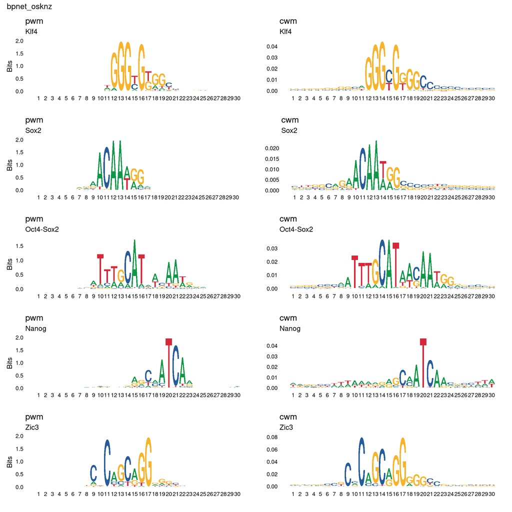

```r
tf_seqlet_ids.df<-data.frame(
      metacluster_name = 'pos_patterns', #Need this if you also have negative patterns
      pattern_name = c('pattern_0', 'pattern_0', 'pattern_0', 'pattern_1', 'pattern_0'),
      motif = c('Klf4', 'Sox2', 'Oct4-Sox2', 'Nanog', 'Zic3'),
      oriented_strand = c('-', '+' , '+', '-', '+'),
      task = c('klf4', 'sox2', 'oct4', 'nanog', 'zic3')
)

bind_logos.plot<-lapply(1:nrow(tf_seqlet_ids.df), function(x){
  pwm = rhdf5::h5read(paste0('modiscolite/bpnet_osknz_fold1_', tf_seqlet_ids.df$task[x],'_counts/modisco.h5'), paste0('pos_patterns/', tf_seqlet_ids.df$pattern_name[x], '/sequence'))
  if(tf_seqlet_ids.df$oriented_strand[x]=='-'){
   pwm = pwm[4:1, ncol(pwm):1] #reverse_complement and custom index
  }
  rownames(pwm)<-c('A','C','G','T')
  pwm.plot<-ggseqlogo(pwm) + ggtitle('pwm', subtitle = tf_seqlet_ids.df$motif[x])

  cwm = rhdf5::h5read(paste0('modiscolite/bpnet_osknz_fold1_', tf_seqlet_ids.df$task[x],'_counts/modisco.h5'), paste0('pos_patterns/', tf_seqlet_ids.df$pattern_name[x], '/contrib_scores'))
  if(tf_seqlet_ids.df$oriented_strand[x]=='-'){
   cwm = cwm[4:1, ncol(cwm):1] #reverse_complement and custom index
  }
  rownames(cwm)<-c('A','C','G','T')
  cwm.plot<-ggseqlogo(cwm, method = 'custom', seq_type='dna') + ggtitle('cwm', subtitle = tf_seqlet_ids.df$motif[x])

  total_plot<-pwm.plot + cwm.plot
}) %>% wrap_plots(ncol = 1) + plot_annotation(title = 'bpnet_osknz')
bind_logos.plot
```

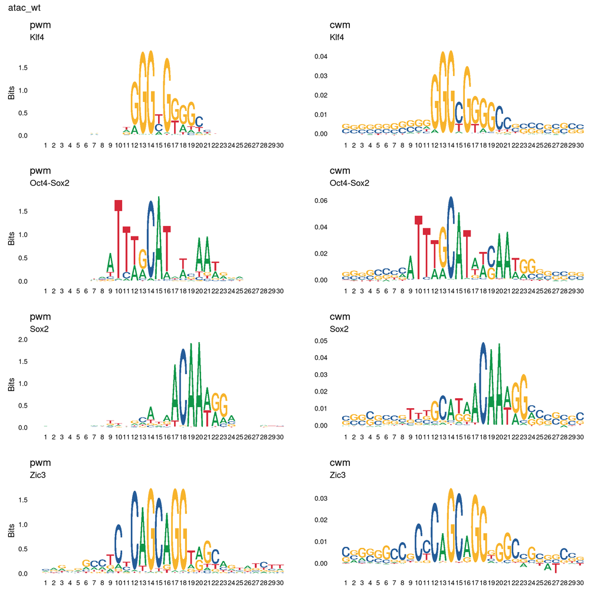

```r
ggsave(paste0(figure_filepath, '/bind_logos.png'), bind_logos.plot, height = 15, width = 10)
ggsave(paste0(figure_filepath, '/bind_logos.pdf'), bind_logos.plot, height = 15, width = 10)

acc_logos.plot<-lapply(1:nrow(acc_seqlet_ids.df), function(x){
  pwm = rhdf5::h5read(paste0('modiscolite/atac_wt_fold1_atac_counts/modisco.h5'), paste0('pos_patterns/', acc_seqlet_ids.df$pattern_name[x], '/sequence'))
  if(acc_seqlet_ids.df$oriented_strand[x]=='-'){
   pwm = pwm[4:1, ncol(pwm):1] #reverse_complement and custom index
  }
  rownames(pwm)<-c('A','C','G','T')
  pwm.plot<-ggseqlogo(pwm) + ggtitle('pwm', subtitle = acc_seqlet_ids.df$motif[x])

  cwm = rhdf5::h5read(paste0('modiscolite/atac_wt_fold1_atac_counts/modisco.h5'), paste0('pos_patterns/', acc_seqlet_ids.df$pattern_name[x], '/contrib_scores'))
  if(acc_seqlet_ids.df$oriented_strand[x]=='-'){
   cwm = cwm[4:1, ncol(cwm):1] #reverse_complement and custom index
  }
  rownames(cwm)<-c('A','C','G','T')
  cwm.plot<-ggseqlogo(cwm, method = 'custom', seq_type='dna') + ggtitle('cwm', subtitle = acc_seqlet_ids.df$motif[x])

  total_plot<-pwm.plot + cwm.plot
}) %>% wrap_plots(ncol = 1) + plot_annotation(title = 'atac_wt')
acc_logos.plot
```

```r
ggsave(paste0(figure_filepath, '/acc_logos.png'), acc_logos.plot, height = 15, width = 10)
ggsave(paste0(figure_filepath, '/acc_logos.pdf'), acc_logos.plot, height = 15, width = 10)
```

## Showcase Jaccard of OS motif

Import PWM and CWM directly from modisco.h5. Remember, this is in the wrong orientation to start.

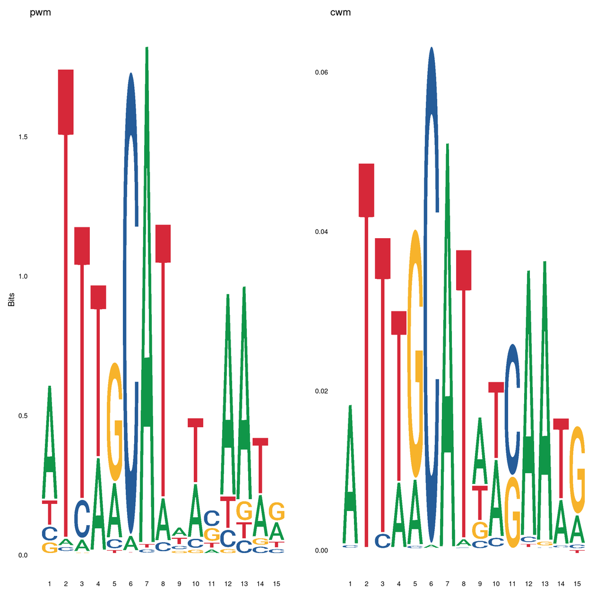

```r
ppm = rhdf5::h5read("modiscolite/atac_wt_fold1_atac_counts/modisco.h5", "pos_patterns/pattern_1/sequence")
ppm = ppm[4:1, 22:8] #reverse_complement and custom index
rownames(ppm)<-c('A','C','G','T')
pwm.plot<-ggseqlogo(ppm) + ggtitle('pwm')

cwm = rhdf5::h5read("modiscolite/atac_wt_fold1_atac_counts/modisco.h5", "pos_patterns/pattern_1/contrib_scores")
cwm = cwm[4:1, 22:8] #reverse_complement and custom index
rownames(cwm)<-c('A','C','G','T')
cwm.plot<-ggseqlogo(cwm, method='custom', seq_type='dna') + ggtitle('cwm')

os_plot<-pwm.plot + cwm.plot
os_plot
```

How do these values get scored? Make a graphic with the Btbd11 enhancer. Note that Jaccard isn’t exactly right, since it doesn’t really calculate in a “genomic position” vector like format. This is a proxy so that people get a sense of what is happening within the algorithm.

```r
os.gr<-GRanges('chr10', IRanges(start = 85539667, end = 85539681))
print(getSeq(bsgenome, os.gr))
```

```
## DNAStringSet object of length 1:
##     width seq
## [1]    15 AATTATAATGATAAT
```

```r
os_seq<-getSeq(bsgenome, os.gr) %>% reverseComplement(.) %>% as.character(.)
print(os_seq)
```

```
## [1] "ATTATCATTATAATT"
```

```r
os_seq_1he<-one_hot_encode_DNA(os_seq)
os_acc_contrib<-rev(standard_metapeak_matrix(os.gr, 'shap/atac_wt_fold1_atac_counts.bw', keep_region_coordinates = T))
os_acc_contrib
```

```
##  [1]  0.050231934  0.102539062  0.127685547  0.019470215  0.034393311
##  [6]  0.069885254  0.103027344  0.112854004  0.020935059  0.006534576
## [11]  0.005439758  0.072875977  0.084472656  0.055633545 -0.008880615
```

```r
pwm.mat<-ppm_to_pwm(ppm = ppm, bg_freq = c(.3, .2, .2,.3))
pwm_match.mat<-one_hot_encode_DNA(os_seq) * pwm.mat
pwm_match.vec<-apply(pwm_match.mat, 2, sum) %>% unlist()
print(pwm_match.vec)
```

```
##           A           T           T           A           T           C
##  1.17721012  1.68751431  1.47168575  0.20919057 -3.58172524  2.26341869
##           A           T           T           A           T           A
##  1.70520687  1.46507889  0.01068024  0.41391522 -1.02016735  1.37086540
##           A           T           T
##  1.41422705  0.70137908 -1.10163844
```

```r
print(round(pwm_match.vec/sum(pwm_match.vec), 2))
```

```
##     A     T     T     A     T     C     A     T     T     A     T     A     A
##  0.14  0.21  0.18  0.03 -0.44  0.28  0.21  0.18  0.00  0.05 -0.12  0.17  0.17
##     T     T
##  0.09 -0.13
```

```r
cwm.mat<-cwm
contrib.mat<-lapply(1:ncol(os_seq_1he), function(x) os_seq_1he[,x]*os_acc_contrib[x]) %>% as.data.frame()
colnames(contrib.mat)<-NULL
contrib.mat
```

```
##
## A 0.05023193 0.0000000 0.0000000 0.01947021 0.00000000 0.00000000 0.1030273
## C 0.00000000 0.0000000 0.0000000 0.00000000 0.00000000 0.06988525 0.0000000
## G 0.00000000 0.0000000 0.0000000 0.00000000 0.00000000 0.00000000 0.0000000
## T 0.00000000 0.1025391 0.1276855 0.00000000 0.03439331 0.00000000 0.0000000
##
## A 0.000000 0.00000000 0.006534576 0.000000000 0.07287598 0.08447266 0.00000000
## C 0.000000 0.00000000 0.000000000 0.000000000 0.00000000 0.00000000 0.00000000
## G 0.000000 0.00000000 0.000000000 0.000000000 0.00000000 0.00000000 0.00000000
## T 0.112854 0.02093506 0.000000000 0.005439758 0.00000000 0.00000000 0.05563354
##
## A  0.000000000
## C  0.000000000
## G  0.000000000
## T -0.008880615
```

```r
#Reimplementing the algorithm from bpreveal.internal.jaccard in a basic way.
cwm.vec<-cwm.mat %>% as.numeric()
contrib.vec<-contrib.mat %>% as.matrix() %>% as.numeric()

#Calculate signs of contrib
cwm.sign.vec<-lapply(cwm.vec, function(x) ifelse(x>=0, 1, -1)) %>% unlist()
contrib.sign.vec<-lapply(contrib.vec, function(x) ifelse(x>=0, 1, -1)) %>% unlist()

#calculate scaled factor
scalefactor<-sum(cwm.mat)/sum(os_acc_contrib)

#Calculate union and intersections
numer.mat<-lapply(1:length(cwm.vec), function(x){min(abs(cwm.vec[x]), abs(contrib.vec[x]*scalefactor))*contrib.sign.vec[x]*cwm.sign.vec[x]}) %>%
  unlist() %>%
  matrix(data = ., nrow = 4, ncol(cwm.mat), byrow = F)

denom.mat<-lapply(1:length(cwm.vec), function(x){max(abs(cwm.vec[x]), abs(contrib.vec[x]))}) %>%
  unlist() %>%
  matrix(data = ., nrow = 4, ncol = ncol(cwm.mat), byrow = F)

jacc_by_base<-colSums(numer.mat/denom.mat)
print(round(jacc_by_base, 2))
```

```
##  [1]  0.35  0.47  0.29  0.43  0.00  0.58  0.49  0.32  0.22  0.39 -0.03  0.46
## [13]  0.42  0.18  0.07
```

```r
jacc_ratio<-c(jacc_by_base/sum(jacc_by_base))
print(round(jacc_ratio, 2))
```

```
##  [1]  0.08  0.10  0.06  0.09  0.00  0.12  0.11  0.07  0.05  0.08 -0.01  0.10
## [13]  0.09  0.04  0.02
```

```r
jacc<-sum(numer.mat)/sum(denom.mat)
print(jacc)
```

```
## [1] 0.3202281
```

# Examine distributions

```r
all_motifs.list<-readRDS('rdata/all_motifs_with_pwm_scores.list.rds')
```

Examine total motifs overlapped.

```r
motif_counts.df<-lapply(tf_seqlet_ids.df$motif, function(x){
  message(x)

  motif.gr<-all_motifs.list[[x]]$motifs
  pwm.gr<-all_motifs.list[[x]]$pwm

  ov<-findOverlaps(motif.gr, pwm.gr, ignore.strand = T)
  motif.gr$pwm_overlap_state<-'bpnet_only'
  motif.gr$pwm_overlap_state[unique(ov@from)]<-'both'
  pwm.gr$pwm_overlap_state<-'pwm_only'
  pwm.gr$pwm_overlap_state[unique(ov@to)]<-'both'

  data.frame(motif = x, pwm_only = length(pwm.gr %>% plyranges::filter(pwm_overlap_state=='pwm_only')),
             both = length(motif.gr %>% plyranges::filter(pwm_overlap_state=='both')),
             cwm_only = length(motif.gr %>% plyranges::filter(pwm_overlap_state=='bpnet_only')))

}) %>% rbindlist() %>%
  dplyr::mutate(motif = factor(motif, levels = names(motif_to_task.list))) %>%
  tidyr::pivot_longer(cols = c(both, cwm_only, pwm_only), names_to = 'mapping', values_to = 'freq')

motif_counts.plot<-ggplot(motif_counts.df, aes(x = motif, y = freq, fill = mapping))+
  geom_bar(stat = 'identity', position = 'dodge') +
  coord_flip()+
  theme_classic()

ggsave(paste0(figure_filepath, '/mapping_counts.png'), motif_counts.plot, height = 4, width = 4)
ggsave(paste0(figure_filepath, '/mapping_counts.pdf'), motif_counts.plot, height = 4, width = 4)
```

Report counts

```r
motif_counts.df %>% dplyr::group_by(mapping) %>%
  dplyr::summarize(counts = sum(freq))
```

```
## # A tibble: 3 × 2
##   mapping   counts
##   <chr>      <int>
## 1 both      336664
## 2 cwm_only   40891
## 3 pwm_only 2870273
```

```r
df<-motif_counts.df %>% dplyr::group_by(mapping) %>%
  dplyr::summarize(counts = sum(freq))
value<-(df %>% dplyr::filter(mapping == 'both') %>% .$counts) / ((df %>% dplyr::filter(mapping == 'both') %>% .$counts) + (df %>% dplyr::filter(mapping == 'cwm_only') %>% .$counts))
message(value, ' rate of CWM belonging to also PWM motifs')
```

Examine sequence match distributions

```
## [1] "bpnet_only: 1364\nboth: 117018\npwm_only: 840657"
```

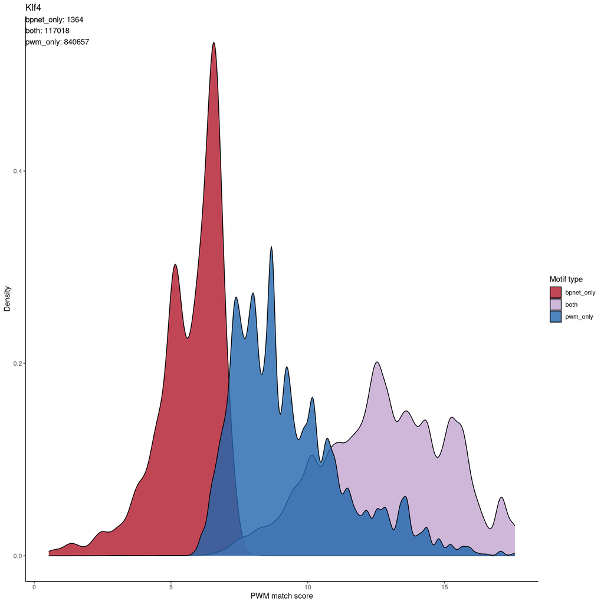

```
## [1] "bpnet_only: 1822\nboth: 57959\npwm_only: 541714"
```

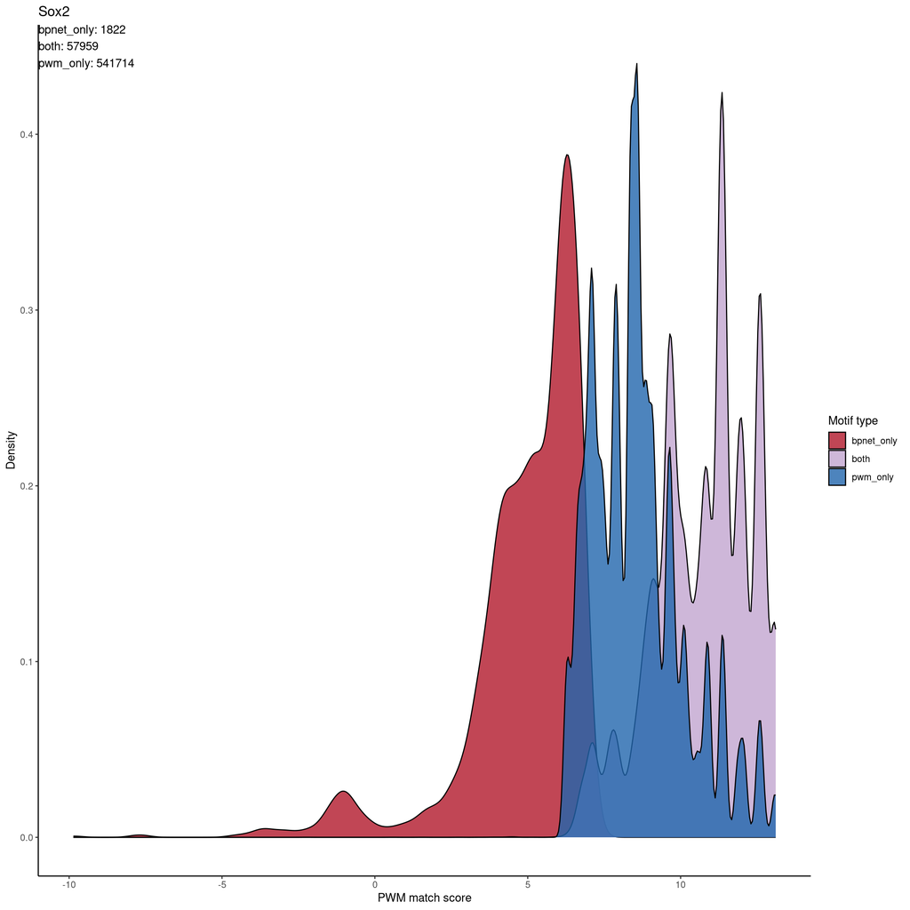

```
## [1] "bpnet_only: 2011\nboth: 38671\npwm_only: 533136"
```

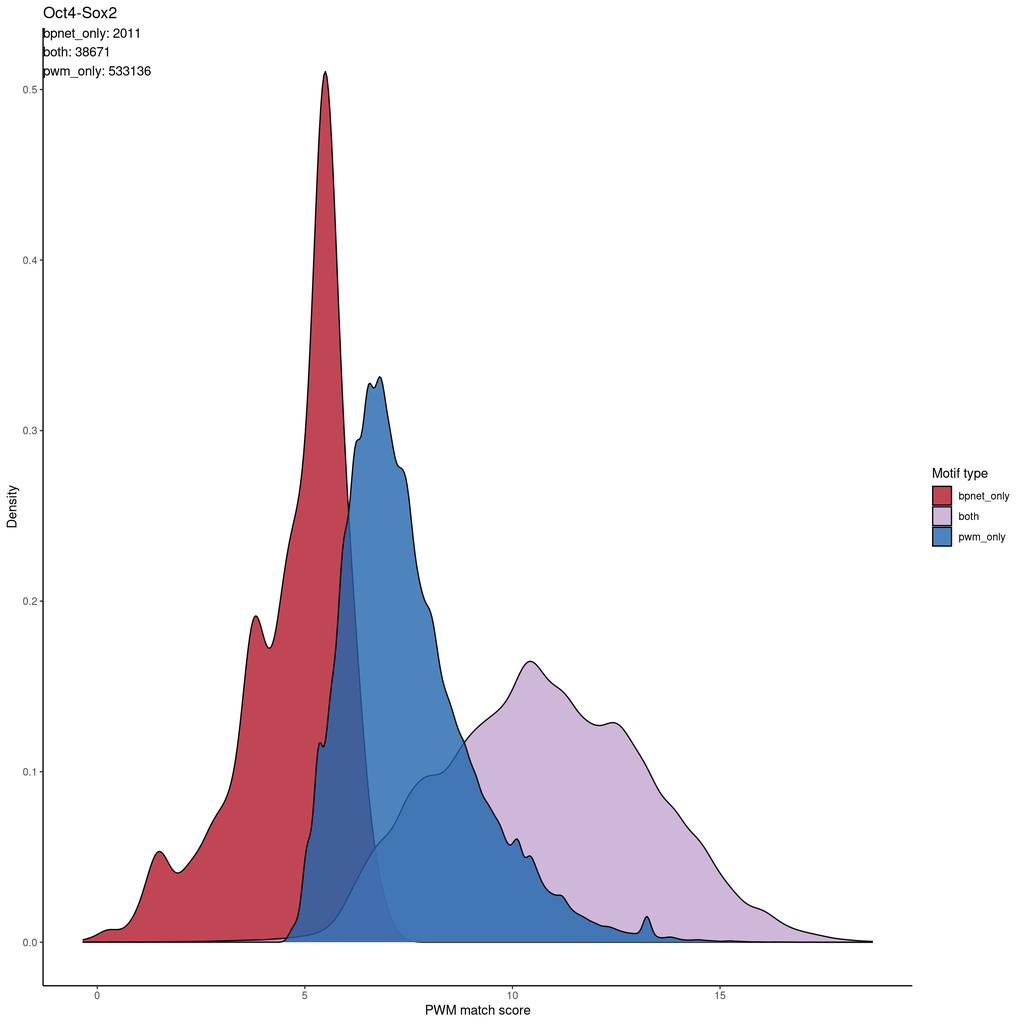

```
## [1] "bpnet_only: 32500\nboth: 33459\npwm_only: 341055"
```

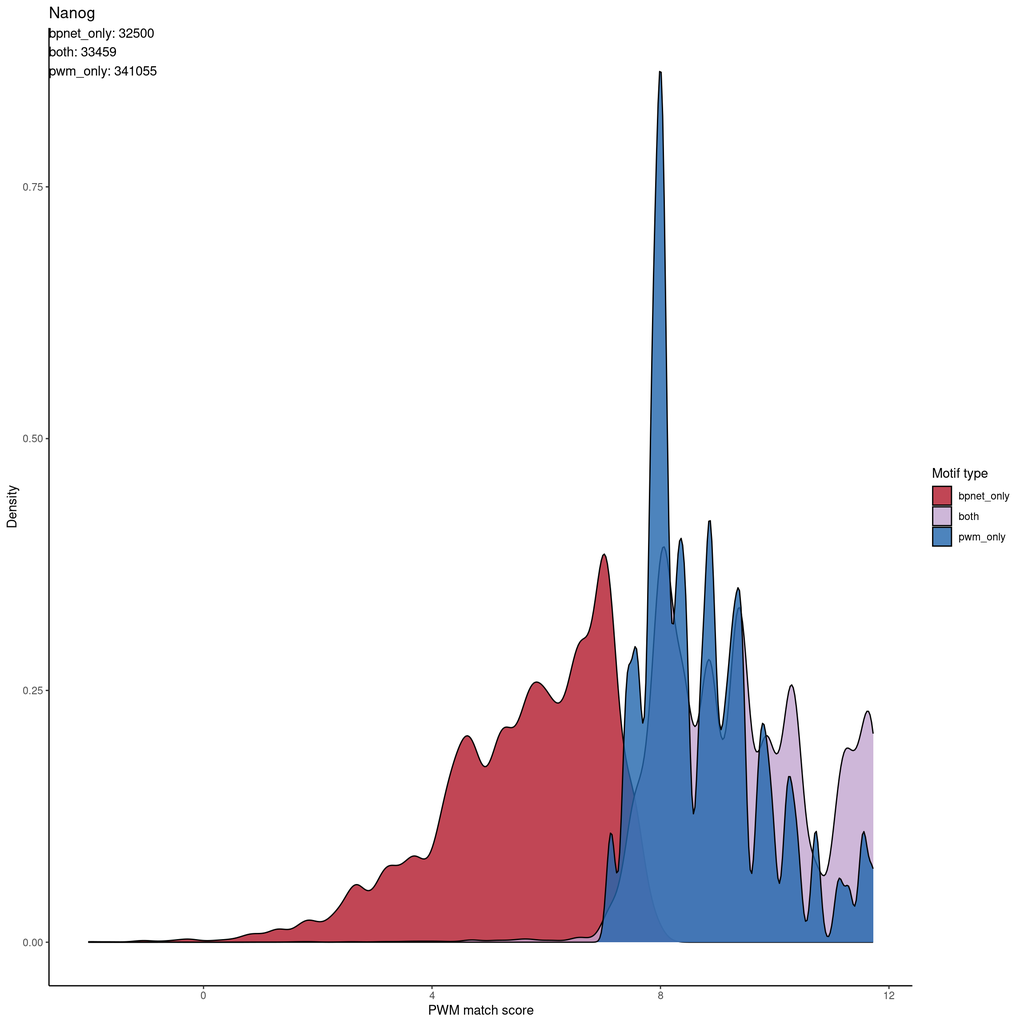

```
## [1] "bpnet_only: 3194\nboth: 89557\npwm_only: 613711"
```

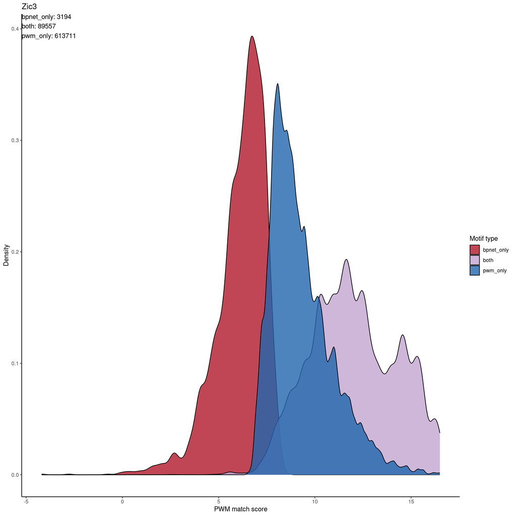

```r
overlap_dist.plot.list<-lapply(tf_seqlet_ids.df$motif, function(x){
  message(x)

  motif.gr<-all_motifs.list[[x]]$motifs
  pwm.gr<-all_motifs.list[[x]]$pwm

  ov<-findOverlaps(motif.gr, pwm.gr, ignore.strand = T)
  motif.gr$pwm_overlap_state<-'bpnet_only'
  motif.gr$pwm_overlap_state[unique(ov@from)]<-'both'
  pwm.gr$pwm_overlap_state<-'pwm_only'
  pwm.gr$pwm_overlap_state[unique(ov@to)]<-'both'

  motif.gr$pwm_overlap_state %>% table
  pwm.gr$pwm_overlap_state %>% table

  combined.df<-rbind(
    motif.gr %>% as.data.frame %>% dplyr::select(motif, pwm_match_score, pwm_overlap_state),
    pwm.gr %>% as.data.frame %>% dplyr::select(motif, pwm_match_score, pwm_overlap_state) %>% dplyr::filter(pwm_overlap_state=='pwm_only')
  ) %>%
    dplyr::mutate(pwm_overlap_state = factor(pwm_overlap_state, levels = c('bpnet_only','both','pwm_only')))

  combined_count_label<-combined.df %>% dplyr::group_by(pwm_overlap_state) %>% dplyr::summarize(counts = dplyr::n()) %>%
    dplyr::mutate(count_label = paste0(pwm_overlap_state, ': ', counts)) %>%
    .$count_label %>% paste0(., collapse = '\n')
  print(combined_count_label)

  g<-ggplot(combined.df, aes(x = pwm_match_score, fill = pwm_overlap_state))+
    geom_density(position = 'identity', alpha = .8)+
    annotate(geom = 'text', x = -Inf, y = Inf, label = combined_count_label, vjust = 1, hjust = 0)+
    scale_x_continuous(name = 'PWM match score')+
    scale_y_continuous(name = 'Density')+
    scale_fill_manual(name = 'Motif type', values = c('#b2182b', '#c2a5cf', '#2166ac'))+
    ggtitle(x)+
    theme_classic()
  print(g)

  return(g)
})
```

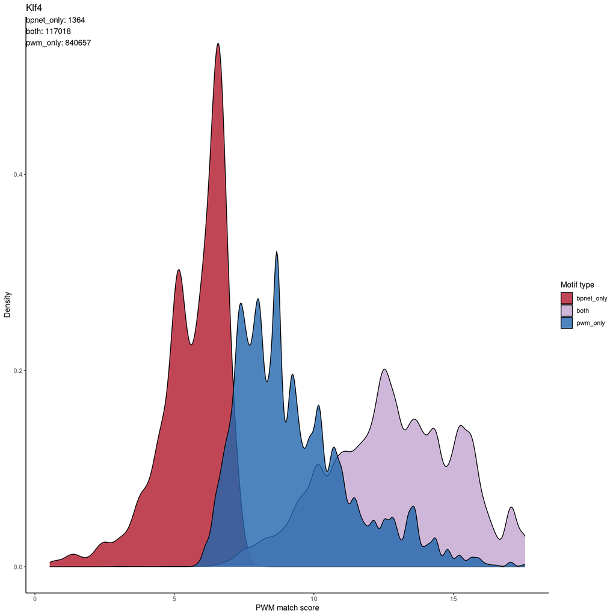

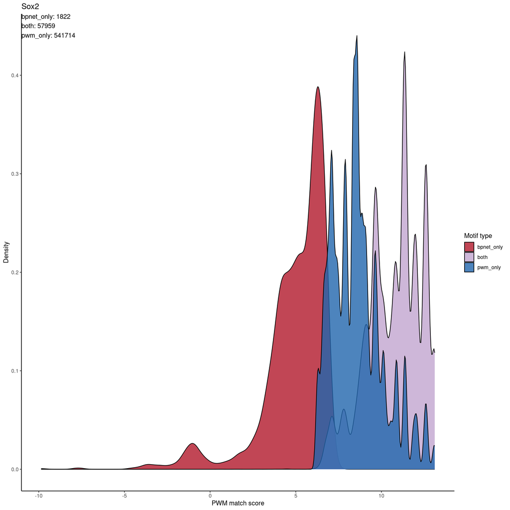

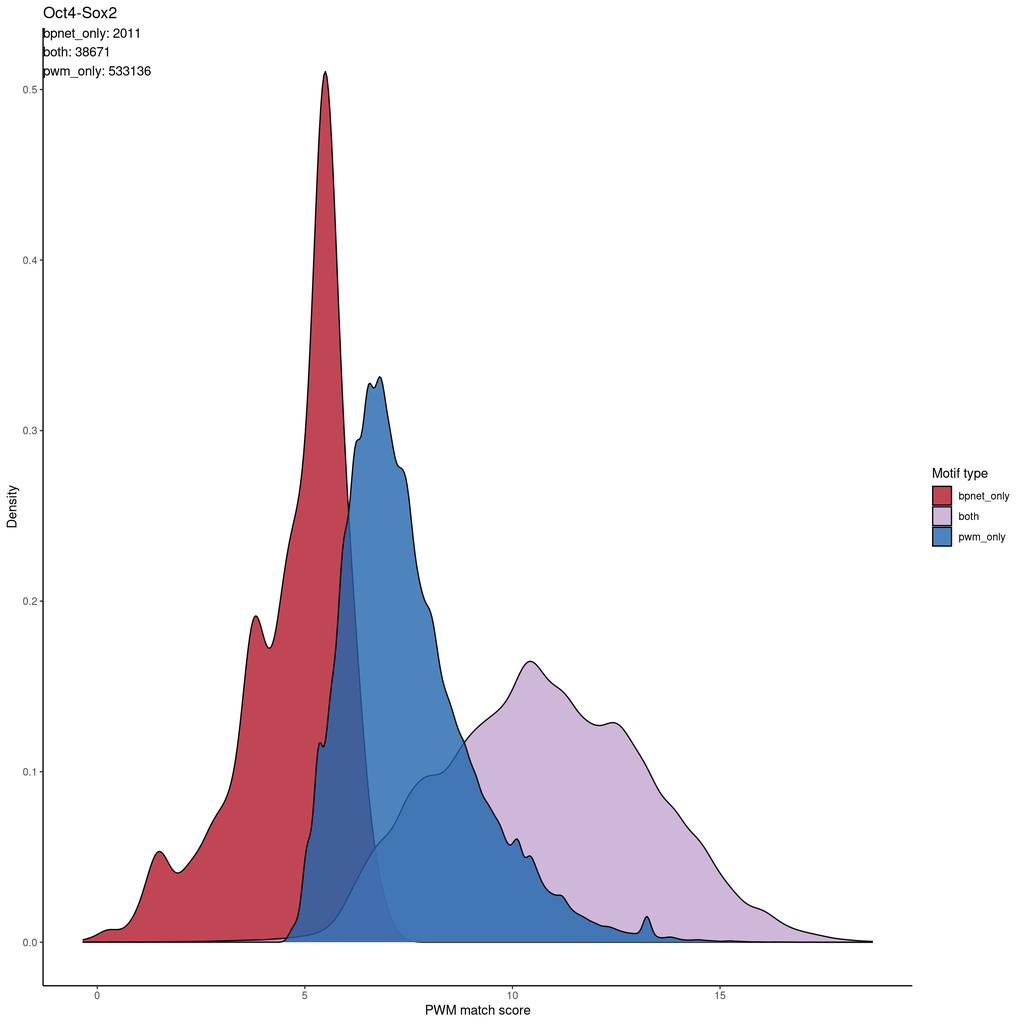

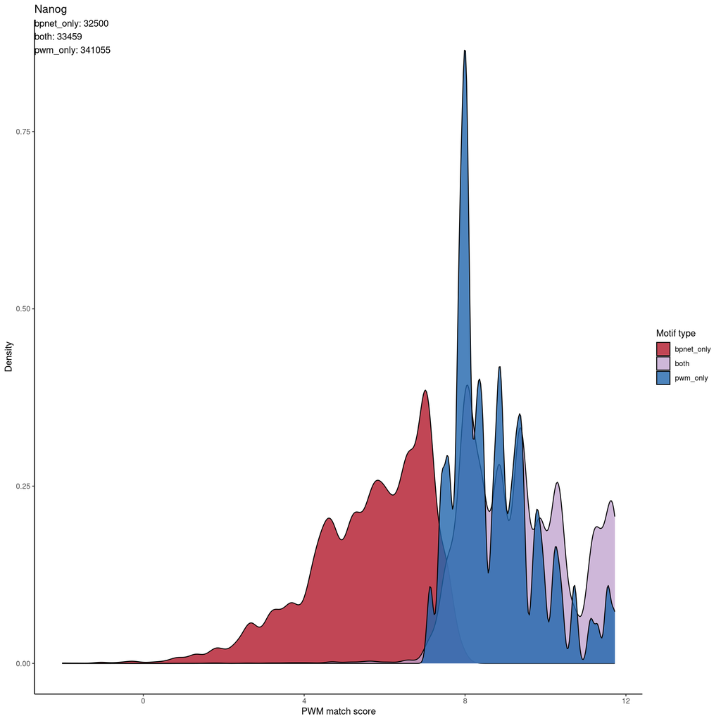

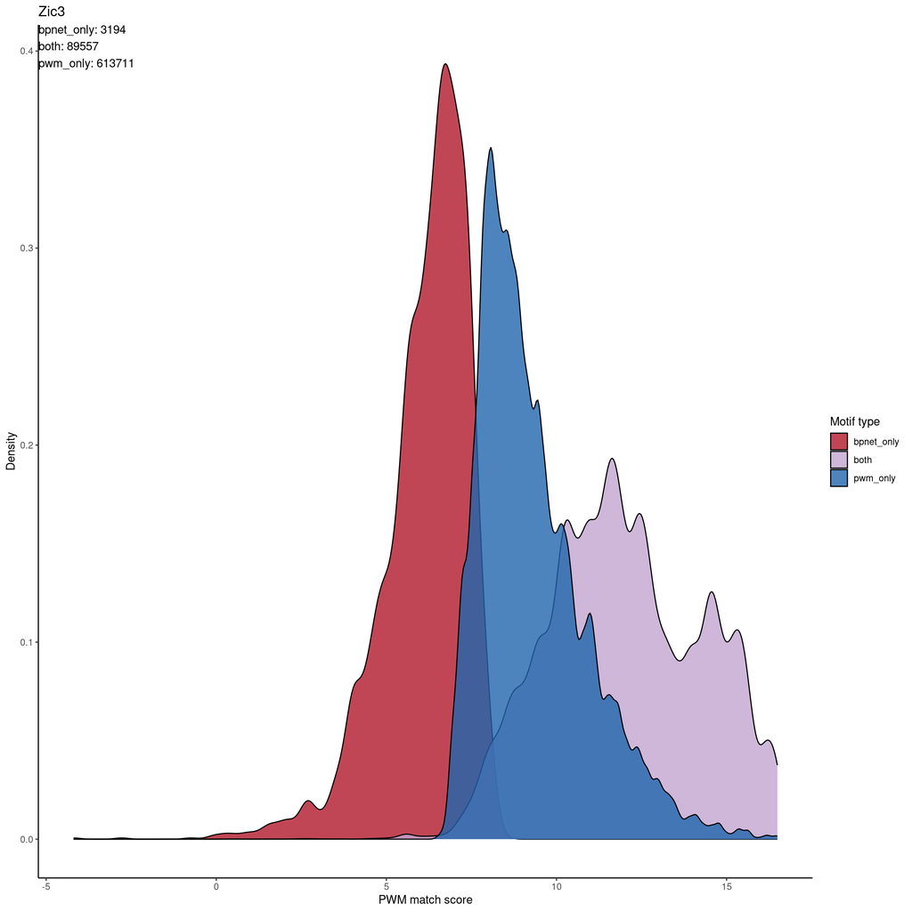

```r
overlap_dist.plot.list
```

# Plot ranked contribution

Get top 2K PWM matches that do not overlap with mapped hits.

```r
nonmotif_contrib.df<-lapply(names(all_motifs.list), function(x){
  message(x)

  motif.gr<-motifs.gr %>% as.data.frame %>% dplyr::filter(motif==x) %>% makeGRangesFromDataFrame(keep.extra.columns = T, starts.in.df.are.0based = F)
  pwm.gr<-all_motifs.list[[x]]$pwm

  ov<-findOverlaps(motifs.gr, pwm.gr, ignore.strand = T)
  pwm.gr$pwm_overlap_state<-'pwm_only'
  pwm.gr$pwm_overlap_state[unique(ov@to)]<-'both'

  nonmotifs.gr<-pwm.gr %>% plyranges::filter(pwm_overlap_state=='pwm_only') %>%
    plyranges::arrange(desc(pwm_match_score)) %>% head(n=2000) %>%
    plyranges::mutate(acc_contrib = regionSums(., 'shap/atac_wt_fold1_atac_counts.bw'),
                      bind_contrib = regionSums(., paste0('shap/bpnet_osknz_fold1_', motif_to_task.list[[x]], '_counts.bw'))) %>%
    dplyr::arrange(desc(bind_contrib))

  ov<-findOverlaps(nonmotifs.gr, regions.gr, ignore.strand = T)
  nonmotifs.gr$region_id<-NA
  nonmotifs.gr$region_id[ov@from]<-regions.gr$region_id[ov@to]
  nonmotifs.df<-nonmotifs.gr %>%
    as.data.frame %>%
    dplyr::filter(!is.na(region_id)) %>%
    dplyr::arrange(desc(bind_contrib)) %>%
    dplyr::left_join(., regions.gr %>% as.data.frame %>% dplyr::select(region_id, atac_obs, CpG_ratio))


  rtracklayer::export(pwm.gr %>%
                        plyranges::filter(pwm_overlap_state=='pwm_only') %>%
                        plyranges::mutate(name = pwm_match_score_q),
                      paste0('bed/mapped_motifs/all_', x, '_pwm_only_motifs.bed'))
  return(nonmotifs.df)
}) %>% rbindlist(.)
nonmotif_contrib.df
```

```
##       seqnames     start       end width strand motif_id motif_alt_id   score
##         <fctr>     <int>     <int> <int> <fctr>   <char>       <lgcl>   <num>
##    1:    chr11  35838498  35838508    11      +     Klf4           NA 15.8202
##    2:     chr4 109666798 109666808    11      -     Klf4           NA 14.8315
##    3:    chr11  80597767  80597777    11      -     Klf4           NA 16.0899
##    4:    chr13 119791157 119791167    11      -     Klf4           NA 15.1573
##    5:     chr5 110448584 110448594    11      -     Klf4           NA 15.9551
##   ---
## 3618:     chr6 144667427 144667437    11      +     Zic3           NA 15.1735
## 3619:     chr1 184814892 184814902    11      +     Zic3           NA 14.9388
## 3620:     chr1 184814842 184814852    11      +     Zic3           NA 14.9388
## 3621:     chr1 184814722 184814732    11      +     Zic3           NA 14.9388
## 3622:     chr2  27720646  27720656    11      +     Zic3           NA 14.9388
##        p.value q.value matched_sequence         seq  motif ic_match_score
##          <num>  <lgcl>           <lgcl>      <char> <char>          <num>
```

[output cut: 37 more lines]

Next, superimpose the ranked hits with the top PWM-matched contribution scores.

```r
motif_contrib.df<-lapply(names(all_motifs.list), function(x){
  message(x)
  motif.df<-motifs.gr %>% as.data.frame %>%
    dplyr::filter(motif==x)

  #Mark which model hits also overlap with PWM hits
  pwm.gr<-all_motifs.list[[x]]$pwm
  motif.df$rank_type<-ifelse(overlapsAny(motif.df %>% makeGRangesFromDataFrame(), pwm.gr, ignore.strand = T),
                              'both', 'model_only')

  ranked_motifs.df<- motif.df %>%
    dplyr::group_by(motif, rank_type) %>%
    dplyr::arrange(desc(acc_contrib)) %>%
    dplyr::mutate(acc_ranked_row = 1:(dplyr::n()),
                  acc_ranked_prop = acc_ranked_row/dplyr::n()) %>%
    dplyr::arrange(desc(bind_contrib)) %>%
    dplyr::mutate(bind_ranked_row = 1:(dplyr::n()),
                  bind_ranked_prop = bind_ranked_row/dplyr::n())

  ranked_pwms.df<-nonmotif_contrib.df %>%
    dplyr::filter(motif==x) %>%
    dplyr::group_by(motif) %>%
    dplyr::arrange(desc(acc_contrib)) %>%
    dplyr::mutate(acc_ranked_row = 1:(dplyr::n()),
                  acc_ranked_prop = acc_ranked_row/dplyr::n()) %>%
    dplyr::arrange(desc(bind_contrib)) %>%
    dplyr::mutate(bind_ranked_row = 1:(dplyr::n()),
                  bind_ranked_prop = bind_ranked_row/dplyr::n())

  rankings.df<-rbind(
    ranked_motifs.df %>% dplyr::select(acc_contrib, bind_contrib, acc_ranked_prop, bind_ranked_prop, rank_type),
    ranked_pwms.df %>% dplyr::mutate(rank_type = 'pwm_only') %>% dplyr::select(acc_contrib, bind_contrib, acc_ranked_prop, bind_ranked_prop, rank_type)
  )

  acc.plot<-ggplot(rankings.df, aes(x = acc_ranked_prop, y = acc_contrib, color = rank_type))+
    geom_hline(yintercept = 0, linetype = 'dashed')+
    geom_line()+
    facet_grid(motif ~ ., scales = 'free')+
    theme_classic()

  bind.plot<-ggplot(rankings.df, aes(x = bind_ranked_prop, y = bind_contrib, color = rank_type))+
    geom_hline(yintercept = 0, linetype = 'dashed')+
    geom_line()+
    facet_grid(motif ~ ., scales = 'free')+
    theme_classic()
  pwm_nonmotif.plot<-ggseqlogo(ranked_pwms.df %>% .$seq) + scale_y_continuous(limits = c(0, 2)) + ggtitle('PWM-only')
  model_only.plot<-ggseqlogo(motif.df %>% dplyr::filter(rank_type=='model_only') %>% .$seq) + scale_y_continuous(limits = c(0, 2)) + ggtitle('model-only')
  both.plot<-ggseqlogo(motif.df %>% dplyr::filter(rank_type=='both') %>% .$seq) + scale_y_continuous(limits = c(0, 2)) + ggtitle('both')

  showcase<-pwm_nonmotif.plot + model_only.plot + both.plot + acc.plot + bind.plot + plot_layout(ncol = 1)
  showcase
  ggsave(paste0(figure_filepath, '/ranked_', x, '_hits_vs_nonmotifs.png'), showcase, height = 12, width = 5)
  ggsave(paste0(figure_filepath, '/ranked_', x, '_hits_vs_nonmotifs.pdf'), showcase, height = 12, width = 5)
})
```

# Create metaplots of motif affinity

## Show high/med/low context/isolation scores

```r
sampled_motif_n<-5000

filler<-mclapply(c('Klf4','Sox2','Oct4-Sox2'), function(x){

    #Next, do this across both binding and accessibility models
    motif_summary.df<-lapply(c('both|acc', 'both|bind', 'both|bind|acc'), function(y){

        message(x, y, ordering_var)

        #Define task-specific binding coverage
        task<-motif_to_task.list[[x]]

        #Extract all CWM scored motifs
        cwm.gr<-motifs.gr %>% plyranges::filter(motif==x, grepl(y, mapping_state)) %>%
          arrange(desc(!!sym(ordering_var))) %>%

          #Import bind_marg and bind_perturb scores etc to the cwm.gr motifs
          as.data.frame %>%
          dplyr::left_join(., readr::read_tsv('tsv/mapped_motifs/all_instances_curated_1based_with_scores.tsv.gz') %>%
                             dplyr::select(motif_id, bind_marg, bind_perturb, acc_marg, acc_perturb)) %>%
          makeGRangesFromDataFrame(keep.extra.columns = T, starts.in.df.are.0based = F)

        #Plot median perturbation/marginalization scores for the motif based on top/mid/bottom status
        motif_summary.df<-c(
          cwm.gr %>% arrange(desc(!!sym(ordering_var))) %>% head(n=sampled_motif_n) %>% dplyr::mutate(mapping = 'top_cwm'),
          cwm.gr %>% arrange(desc(!!sym(ordering_var))) %>% head(n=floor(length(cwm.gr)/2) + floor(sampled_motif_n/2)) %>%
            tail(n=sampled_motif_n) %>% dplyr::mutate(mapping = 'mid_cwm'),
          cwm.gr %>% arrange(!!sym(ordering_var)) %>% head(n=sampled_motif_n) %>% dplyr::mutate(mapping = 'bottom_cwm')
        ) %>%
          as.data.frame %>%
          dplyr::group_by(mapping, seq) %>%
          #First, take median to get standard response across each individual sequence
          dplyr::summarize(bind_marg = median(bind_marg),
                           bind_perturb = median(bind_perturb),
                           acc_marg = median(acc_marg),
                           acc_perturb = median(acc_perturb)) %>%

          #Then, take median across each individual sequences, then summarize
          dplyr::group_by(mapping) %>%
          dplyr::summarize(med_bind_marg = median(bind_marg),
                           med_bind_perturb = median(bind_perturb),
                           med_acc_marg = median(acc_marg),
                           med_acc_perturb = median(acc_perturb)) %>%
          as.data.table %>%
          melt.data.table(id.vars = 'mapping') %>%
          tidyr::separate(col = variable, into = c(NA, 'model', 'pred_type'), sep = '_') %>%
          dplyr::mutate(pred_type = factor(pred_type, c('perturb', 'marg'))) %>%
          dplyr::mutate(mapping_state = y)
    }) %>% rbindlist()

    #Summarize median marginaliztion scores as a bar plot
    summary.plot<-ggplot(motif_summary.df, aes(x = mapping, y = value, fill = pred_type))+
      geom_bar(stat = 'identity', position = 'dodge')+
      facet_grid(mapping_state ~ model)+
      theme_classic() + theme(legend.position = 'bottom')
    summary.plot
    ggsave(paste0(figure_filepath, '/motif_response_summary_across_affinities_', x, '_ord_by_', ordering_var, '.png'), summary.plot, height = 4, width = 4)
    ggsave(paste0(figure_filepath, '/motif_response_summary_across_affinities_', x, '_ord_by_', ordering_var, '.pdf'), summary.plot, height = 4, width = 4)

  }, mc.cores = 3)
```

## Plot PWM score distributions

```r
sampled_motif_n<-5000

#First, order all heatmaps either by seuqence match or total binding levels of motif
plot.list<-mclapply(names(all_motifs.list), function(x){

    #Next, do this across both binding and accessibility models
    lapply(c('acc', 'bind'), function(y){

      #Filter out Nanog motifs from accessibility models (they dont exist)
      if(!((x=='Nanog') & (y=='acc'))){

        message(x, y)

        #Extract all CWM scored motifs
        cwm.gr<-motifs.gr %>% plyranges::filter(motif==x, mapping_state %in% c('both', y))
        cwm.df<-cwm.gr %>% as.data.frame %>%
          dplyr::left_join(all_motifs.list[[x]]$motifs %>% as.data.frame %>% dplyr::select(motif_id, pwm_match_score)) %>%
          dplyr::arrange(desc(pwm_match_score))

        #Extract all PWM scored motifs
        pwm.gr<-all_motifs.list[[x]]$pwms
        pwm_only.df<-pwm.gr[overlapsAny(pwm.gr, rtracklayer::import(paste0('bed/mapped_motifs/all_', x, '_pwm_only_motifs.bed')), ignore.strand = T)] %>%
          as.data.frame %>%
          plyranges::arrange(desc(pwm_match_score)) %>% head(sampled_motif_n)

        #Plot PWM scores of side features
        cwm_pwm_score_side.plot<-cwm.df %>%
          dplyr::mutate(row = 1:nrow(.)) %>%
          ggplot(., aes(y = pwm_match_score, x = row))+
          ggrastr::rasterize(geom_bar(stat = 'identity', color = '#c2b59b'), dpi=300) +
          scale_y_continuous(limits = c(0, 15), expand = c(0,0))+
          scale_x_continuous(expand=c(0,0))+
          coord_flip()+
          theme_classic()

        pwm_pwm_score_side.plot<-pwm_only.df %>%
          dplyr::mutate(row = 1:nrow(.)) %>%
          ggplot(., aes(y = pwm_match_score, x = row))+
          ggrastr::rasterize(geom_bar(stat = 'identity', color = '#c2b59b'), dpi=300) +
          scale_y_continuous(limits = c(0, 15), expand = c(0,0))+
          scale_x_continuous(expand=c(0,0))+
          coord_flip()+
          theme_classic()

        pwm_score_side.plot<-cwm_pwm_score_side.plot + pwm_pwm_score_side.plot
        ggsave(paste0(figure_filepath, '/pwm_score_side_plot_', y, '_', x, '.png'), pwm_score_side.plot, height = 6, width = 3)
        ggsave(paste0(figure_filepath, '/pwm_score_side_plot_', y, '_', x, '.pdf'), pwm_score_side.plot, height = 6, width = 3)
      }
    })
    return(plot)
  })
```

## Validate that PWM-only motifs do not maintain good coverage

Plot direct coverage of motifs based on two mapping strategies.

```r
sampled_motif_n<-5000

#First, order all heatmaps either by seuqence match or total binding levels of motif
plot.list<-lapply(c('binding_levels', 'seq_match_quantile'), function(ordering_var){

  #Do this across all motifs
  mclapply(names(all_motifs.list), function(x){

    #Next, do this across both binding and accessibility models
    lapply(c('acc', 'bind'), function(y){

      #Filter out Nanog motifs from accessibility models (they dont exist)
      if(!((x=='Nanog') & (y=='acc'))){

        message(x, y, ordering_var)

        #Define task-specific binding coverage
        task<-motif_to_task.list[[x]]
        bind.cov<-list(pos = paste0('bw/mesc_', task, '_nexus_combined_normalized_positive.bw'),
                       neg =  paste0('bw/mesc_', task, '_nexus_combined_normalized_negative.bw'))

        #Extract all PWM scored motifs
        pwm.gr<-rtracklayer::import(paste0('bed/mapped_motifs/all_', x, '_pwm_only_motifs.bed')) %>%
          plyranges::mutate(obs_atac = regionSums(resize(., 1000, 'center'), 'bw/mesc_native_atac_combined.bw'),
                            binding_levels = regionSums(resize(., 1000, 'center'), bind.cov$pos) + abs(regionSums(resize(., 1000, 'center'), bind.cov$neg)),
                            seq_match_quantile = score)

        #Extract all CWM scored motifs
        cwm.gr<-motifs.gr %>% plyranges::filter(motif==x, mapping_state %in% c('both', y)) %>%
          plyranges::mutate(obs_atac = regionSums(resize(., 1000, 'center'), 'bw/mesc_native_atac_combined.bw'),
                            binding_levels = regionSums(resize(., 1000, 'center'), bind.cov$pos) + abs(regionSums(resize(., 1000, 'center'), bind.cov$neg))) %>%
          arrange(desc(!!sym(ordering_var))) %>%

          #Import bind_marg and bind_perturb scores etc to the cwm.gr motifs
          as.data.frame %>%
          dplyr::left_join(., readr::read_tsv('tsv/mapped_motifs/all_instances_curated_1based_with_scores.tsv.gz') %>%
                             dplyr::select(motif_id, bind_marg, bind_perturb, acc_marg, acc_perturb)) %>%
          makeGRangesFromDataFrame(keep.extra.columns = T, starts.in.df.are.0based = F)

        #Print information about how many motifs come from each model
        print(table(cwm.gr %>% arrange(desc(!!sym(ordering_var))) %>% head(n=sampled_motif_n) %>% .$mapping_state))
        print(table(cwm.gr %>% arrange(!!sym(ordering_var)) %>% head(n=sampled_motif_n) %>% .$mapping_state))

        #Collect binding/metapeak information of top/med/bottom/PWM motifs
        if(length(cwm.gr)<10000){
          bottom_n<-length(cwm.gr) - sampled_motif_n
        } else{
          bottom_n<-sampled_motif_n
        }

        bind.df<-rbind(
          pwm.gr %>%
            arrange(desc(!!sym(ordering_var))) %>% head(n=sampled_motif_n) %>% resize(., 1, 'center') %>%
            exo_metapeak(gr = ., sample = bind.cov, upstream = 51, downstream = 50) %>%
            dplyr::mutate(mapping = 'pwm'),
          cwm.gr %>% arrange(desc(!!sym(ordering_var))) %>% head(n=sampled_motif_n) %>% resize(., 1, 'center') %>%
            exo_metapeak(gr = ., sample = bind.cov, upstream = 51, downstream = 50) %>%
            dplyr::mutate(mapping = 'top_cwm'),
          cwm.gr %>% arrange(desc(!!sym(ordering_var))) %>% head(n=floor(length(cwm.gr)/2) + floor(sampled_motif_n/2)) %>%
            tail(n=sampled_motif_n) %>% resize(., 1, 'center') %>%
            exo_metapeak(gr = ., sample = bind.cov, upstream = 51, downstream = 50) %>%
            dplyr::mutate(mapping = 'mid_cwm'),
          cwm.gr %>% arrange(!!sym(ordering_var)) %>% head(n=bottom_n) %>% resize(., 1, 'center') %>%
            exo_metapeak(gr = ., sample = bind.cov, upstream = 51, downstream = 50) %>%
            dplyr::mutate(mapping = 'bottom_cwm')
        ) %>%
          dplyr::mutate(mapping = factor(mapping, levels = c('pwm', 'top_cwm','bottom_cwm', 'mid_cwm')))

        # Plot binding/metapeak information
        bind.plot<-ggplot(bind.df, aes(x = tss_distance, y = reads, group = interaction(strand, mapping), color = mapping))+
          geom_line()+
          scale_x_continuous(name = 'Distance from mapped OS motif')+
          scale_y_continuous(name = paste0('Norm ', task, ' reads'))+
          scale_color_manual(values = c('black', '#e31a1c', '#1f78b4', 'purple'))+
          ggtitle(y)+
          theme_classic() + theme(legend.position = 'bottom')

        if(x=='Oct4-Sox2'){
          sox2_bind.cov<-list(pos = paste0('bw/mesc_sox2_nexus_combined_normalized_positive.bw'),
                              neg =  paste0('bw/mesc_sox2_nexus_combined_normalized_negative.bw'))
          sox2_bind.df<-rbind(
            pwm.gr %>%
              arrange(desc(!!sym(ordering_var))) %>% head(n=sampled_motif_n) %>% resize(., 1, 'center') %>%
              exo_metapeak(gr = ., sample = sox2_bind.cov, upstream = 51, downstream = 50) %>%
              dplyr::mutate(mapping = 'pwm'),
            cwm.gr %>% arrange(desc(!!sym(ordering_var))) %>% head(n=sampled_motif_n) %>% resize(., 1, 'center') %>%
              exo_metapeak(gr = ., sample = sox2_bind.cov, upstream = 51, downstream = 50) %>%
              dplyr::mutate(mapping = 'top_cwm'),
            cwm.gr %>% arrange(desc(!!sym(ordering_var))) %>% head(n=floor(length(cwm.gr)/2) + floor(sampled_motif_n/2)) %>%
              tail(n=sampled_motif_n) %>% resize(., 1, 'center') %>%
              exo_metapeak(gr = ., sample = sox2_bind.cov, upstream = 51, downstream = 50) %>%
              dplyr::mutate(mapping = 'mid_cwm'),
            cwm.gr %>% arrange(!!sym(ordering_var)) %>% head(n=bottom_n) %>% resize(., 1, 'center') %>%
              exo_metapeak(gr = ., sample = sox2_bind.cov, upstream = 51, downstream = 50) %>%
              dplyr::mutate(mapping = 'bottom_cwm')
          ) %>%
            dplyr::mutate(mapping = factor(mapping, levels = c('pwm', 'top_cwm','bottom_cwm', 'mid_cwm')))

          # Plot binding/metapeak information
          sox2_bind.plot<-ggplot(sox2_bind.df, aes(x = tss_distance, y = reads, group = interaction(strand, mapping), color = mapping))+
            geom_line()+
            scale_x_continuous(name = 'Distance from mapped OS motif')+
            scale_y_continuous(name = paste0('Norm sox2 reads'))+
            scale_color_manual(values = c('black', '#e31a1c', '#1f78b4', 'purple'))+
            ggtitle('Sox2 at OS motif', subtitle = y)+
            theme_classic() + theme(legend.position = 'bottom')
```

```r
        }

        #Collect accessibility/metapeak information of top/med/bottom/PWM motifs
        acc.df<-rbind(
          pwm.gr %>%
            arrange(desc(!!sym(ordering_var))) %>% head(n=sampled_motif_n) %>% resize(., 1, 'center') %>%
            standard_metapeak(gr = ., sample = 'bw/mesc_native_atac_cutsites_combined.bw', upstream = 1001, downstream = 1000) %>%
            dplyr::mutate(mapping = 'pwm'),
          cwm.gr %>% arrange(desc(seq_match_quantile)) %>% head(n=sampled_motif_n) %>% resize(., 1, 'center') %>%
            standard_metapeak(gr = ., sample = 'bw/mesc_native_atac_cutsites_combined.bw', upstream = 1001, downstream = 1000) %>%
            dplyr::mutate(mapping = 'top_cwm'),
          cwm.gr %>% arrange(desc(seq_match_quantile)) %>% head(n=floor(length(cwm.gr)/2) + floor(sampled_motif_n/2)) %>%
            tail(n=sampled_motif_n) %>% resize(., 1, 'center') %>%
            standard_metapeak(gr = ., sample = 'bw/mesc_native_atac_cutsites_combined.bw', upstream = 1001, downstream = 1000) %>%
            dplyr::mutate(mapping = 'mid_cwm'),
          cwm.gr %>% arrange(seq_match_quantile) %>% head(n=bottom_n) %>% resize(., 1, 'center')  %>%
            standard_metapeak(gr = ., sample = 'bw/mesc_native_atac_cutsites_combined.bw', upstream = 1001, downstream = 1000) %>%
            dplyr::mutate(mapping = 'bottom_cwm')
        ) %>%
          dplyr::mutate(mapping = factor(mapping, levels = c('pwm', 'top_cwm','bottom_cwm', 'mid_cwm')))

        # Plot accessibility/metapeak information
        acc.plot<-ggplot(acc.df, aes(x = tss_distance, y = reads, color = mapping))+
          geom_line()+
          scale_x_continuous(name = 'Distance from mapped OS motif')+
          scale_y_continuous(name = 'Acc. fragments', limits = c(0, 7))+
          scale_color_manual(values = c('black', '#e31a1c', '#1f78b4', 'purple'))+
          ggtitle(y)+
          theme_classic() + theme(legend.position = 'bottom')

        #Extract logos of subsampled motif groups and plot
        logo.list<-list(pwm = pwm.gr %>% arrange(desc(!!sym(ordering_var))) %>% head(n=sampled_motif_n) %>% getSeq(bsgenome, ., as.character = T),
                        top_cwm = cwm.gr %>% arrange(desc(!!sym(ordering_var))) %>%
                          head(n=sampled_motif_n) %>% getSeq(bsgenome, ., as.character = T),
                        mid_cwm = cwm.gr %>% arrange(desc(!!sym(ordering_var))) %>%
                          head(n=floor(length(cwm.gr)/2) + floor(sampled_motif_n/2)) %>%
                          tail(n=sampled_motif_n) %>% getSeq(bsgenome, ., as.character = T),
                        bottom_cwm = cwm.gr %>% arrange(!!sym(ordering_var)) %>%
                          head(n=bottom_n) %>% getSeq(bsgenome, ., as.character = T))
        logo.plot<-ggplot() + geom_logo(logo.list) + theme_logo() +
          facet_wrap(~seq_group, ncol=1, scales='free_x')  +
          ggtitle(y)

        #Plot heatmps of metaplots. We will order them based on the the ordering variable assigned
        atac_heatmap.plot<-plot_standard_heatmap_local(regions.gr = GenomicRanges::resize(cwm.gr, 1, 'center'),
                                                       sample = 'bw/mesc_native_atac_combined.bw', title = 'ATAC frag',
                                                       order = 'asis', upstream = 1001, downstream = 1000, removal_threshold = .2, normalize_threshold = .99,
                                                       color_vec = c('white', '#f7fcfd','#e0ecf4','#bfd3e6','#9ebcda','#8c96c6','#8c6bb1','#88419d','#810f7c','#4d004b')) +
          theme(axis.text.y = element_blank(), axis.title.y = element_blank())
        nexus_heatmap.plot<-plot_standard_heatmap_local(regions.gr = GenomicRanges::resize(cwm.gr, 1, 'center'),# %>% head(n=1000),
                                                        sample = paste0('bw/mesc_', task, '_nexus_combined_grouped.bw'), title = 'Task ChIP-nexus',
                                                        order = 'asis', upstream = 101, downstream = 100, removal_threshold = .95, normalize_threshold = 1,
                                                        color_vec = c('white', '#fff7ec','#fee8c8','#fdd49e','#fdbb84','#fc8d59','#ef6548','#d7301f','#b30000','#7f0000')) +
          theme(axis.text.y = element_blank(), axis.title.y = element_blank())
        #Always add Sox2 heatmap side-by-side for the Oct4-Sox2 side-by-side
        sox2_nexus_heatmap.plot<-plot_standard_heatmap_local(regions.gr = GenomicRanges::resize(cwm.gr, 1, 'center'),# %>% head(n=1000),
                                                             sample = paste0('bw/mesc_sox2_nexus_combined_grouped.bw'), title = 'Sox2 ChIP-nexus',
                                                             order = 'asis', upstream = 101, downstream = 100, removal_threshold = .95, normalize_threshold = 1,
                                                             color_vec = c('#fff7fb','#ece7f2','#d0d1e6','#a6bddb','#74a9cf','#3690c0','#0570b0','#045a8d','#023858')) +
          theme(axis.text.y = element_blank(), axis.title.y = element_blank())

        seqs.plot<-plot_sequence(gr = resize(rev(cwm.gr), 1, 'center'), title = 'motif seqs', window = 15, genome = bsgenome, show = F)$plot +
          theme(axis.text.y = element_blank(), axis.title.y = element_blank())

        #Save these metaplots
        if(x=='Oct4-Sox2'){
          plot<-bind.plot + sox2_bind.plot + acc.plot + logo.plot + seqs.plot + nexus_heatmap.plot + sox2_nexus_heatmap.plot + atac_heatmap.plot + plot_layout(nrow = 1)
        }else{
          plot<-bind.plot + acc.plot + logo.plot + seqs.plot + nexus_heatmap.plot + sox2_nexus_heatmap.plot + atac_heatmap.plot + plot_layout(nrow = 1)
        }
        ggsave(paste0(figure_filepath, '/metaplots_', y, '_pwm_vs_cwm_across_coverage_', x, '_ord_by_', ordering_var, '.png'), plot, height = 5, width = 15)
        ggsave(paste0(figure_filepath, '/metaplots_', y, '_pwm_vs_cwm_across_coverage_', x, '_ord_by_', ordering_var, '.pdf'), plot, height = 5, width = 15)
```

```r
        #Next, save the suballocated top/mid/bottom heatmaps of these motifs
        plot.list<-list(
          #Task based coverage
          plot_standard_heatmap_local(regions.gr = pwm.gr %>% arrange(desc(!!sym(ordering_var))) %>% head(n=sampled_motif_n) %>%
                                        plyranges::mutate(task_binding = regionSums(resize(., 100, 'center'), bind.cov$pos) +
                                                            abs(regionSums(resize(., 100, 'center'), bind.cov$neg))) %>%
                                        plyranges::arrange(desc(task_binding)) %>%
                                        resize(., 1, 'center'),
                                      sample = paste0('bw/mesc_', task, '_nexus_combined_grouped.bw'), title = 'PWM 5K Task ChIP-nexus',
                                      order = 'asis', upstream = 101, downstream = 100, removal_threshold = .95, normalize_threshold = 1,
                                      color_vec = c('white', '#fff7ec','#fee8c8','#fdd49e','#fdbb84','#fc8d59','#ef6548','#d7301f','#b30000','#7f0000')) +
            theme(axis.text.y = element_blank(), axis.title.y = element_blank()),

          plot_standard_heatmap_local(regions.gr = cwm.gr %>% arrange(desc(!!sym(ordering_var))) %>% head(n=sampled_motif_n) %>%
                                        plyranges::mutate(task_binding = regionSums(resize(., 100, 'center'), bind.cov$pos) +
                                                            abs(regionSums(resize(., 100, 'center'), bind.cov$neg))) %>%
                                        plyranges::arrange(desc(task_binding)) %>%
                                        resize(., 1, 'center'),
                                      sample = paste0('bw/mesc_', task, '_nexus_combined_grouped.bw'), title = 'Top 5K Task ChIP-nexus',
                                      order = 'asis', upstream = 101, downstream = 100, removal_threshold = .95, normalize_threshold = 1,
                                      color_vec = c('white', '#fff7ec','#fee8c8','#fdd49e','#fdbb84','#fc8d59','#ef6548','#d7301f','#b30000','#7f0000')) +
            theme(axis.text.y = element_blank(), axis.title.y = element_blank()),
          plot_standard_heatmap_local(regions.gr = cwm.gr %>% arrange(desc(!!sym(ordering_var))) %>% head(n=floor(length(cwm.gr)/2) + floor(sampled_motif_n/2)) %>% tail(n=sampled_motif_n) %>%
                                        plyranges::mutate(task_binding = regionSums(resize(., 100, 'center'), bind.cov$pos) +
                                                            abs(regionSums(resize(., 100, 'center'), bind.cov$neg))) %>%
                                        plyranges::arrange(desc(task_binding)) %>%
                                        resize(., 1, 'center'),
                                      sample = paste0('bw/mesc_', task, '_nexus_combined_grouped.bw'), title = 'Mid 5K Task ChIP-nexus',
                                      order = 'asis', upstream = 101, downstream = 100, removal_threshold = .95, normalize_threshold = 1,
                                      color_vec = c('white', '#fff7ec','#fee8c8','#fdd49e','#fdbb84','#fc8d59','#ef6548','#d7301f','#b30000','#7f0000')) +
            theme(axis.text.y = element_blank(), axis.title.y = element_blank()),
          plot_standard_heatmap_local(regions.gr = cwm.gr %>% arrange(!!sym(ordering_var)) %>% head(n=sampled_motif_n) %>%
                                        plyranges::mutate(task_binding = regionSums(resize(., 100, 'center'), bind.cov$pos) +
                                                            abs(regionSums(resize(., 100, 'center'), bind.cov$neg))) %>%
                                        plyranges::arrange(desc(task_binding)) %>%
                                        resize(., 1, 'center'),
                                      sample = paste0('bw/mesc_', task, '_nexus_combined_grouped.bw'), title = 'Bottom 5K Task ChIP-nexus',
                                      order = 'asis', upstream = 101, downstream = 100, removal_threshold = .95, normalize_threshold = 1,
                                      color_vec = c('white', '#fff7ec','#fee8c8','#fdd49e','#fdbb84','#fc8d59','#ef6548','#d7301f','#b30000','#7f0000')) +
            theme(axis.text.y = element_blank(), axis.title.y = element_blank()),

          #Sox2 based coverage
          plot_standard_heatmap_local(regions.gr = pwm.gr %>% arrange(desc(!!sym(ordering_var))) %>% head(n=sampled_motif_n) %>%
                                        plyranges::mutate(task_binding = regionSums(resize(., 100, 'center'), bind.cov$pos) +
                                                            abs(regionSums(resize(., 100, 'center'), bind.cov$neg))) %>%
                                        plyranges::arrange(desc(task_binding)) %>%
                                        resize(., 1, 'center'),
                                      sample = paste0('bw/mesc_sox2_nexus_combined_grouped.bw'), title = 'PWM 5K Sox2 ChIP-nexus',
                                      order = 'asis', upstream = 101, downstream = 100, removal_threshold = .95, normalize_threshold = 1,
                                      color_vec = c('#fff7fb','#ece7f2','#d0d1e6','#a6bddb','#74a9cf','#3690c0','#0570b0','#045a8d','#023858')) +
            theme(axis.text.y = element_blank(), axis.title.y = element_blank()),

          plot_standard_heatmap_local(regions.gr = cwm.gr %>% arrange(desc(!!sym(ordering_var))) %>% head(n=sampled_motif_n) %>%
                                        plyranges::mutate(task_binding = regionSums(resize(., 100, 'center'), bind.cov$pos) +
                                                            abs(regionSums(resize(., 100, 'center'), bind.cov$neg))) %>%
                                        plyranges::arrange(desc(task_binding)) %>%
                                        resize(., 1, 'center'),
                                      sample = paste0('bw/mesc_sox2_nexus_combined_grouped.bw'), title = 'Top 5K Sox2 ChIP-nexus',
                                      order = 'asis', upstream = 101, downstream = 100, removal_threshold = .95, normalize_threshold = 1,
                                      color_vec = c('#fff7fb','#ece7f2','#d0d1e6','#a6bddb','#74a9cf','#3690c0','#0570b0','#045a8d','#023858')) +
            theme(axis.text.y = element_blank(), axis.title.y = element_blank()),
          plot_standard_heatmap_local(regions.gr = cwm.gr %>% arrange(desc(!!sym(ordering_var))) %>% head(n=floor(length(cwm.gr)/2) + floor(sampled_motif_n/2)) %>% tail(n=sampled_motif_n) %>%
                                        plyranges::mutate(task_binding = regionSums(resize(., 100, 'center'), bind.cov$pos) +
                                                            abs(regionSums(resize(., 100, 'center'), bind.cov$neg))) %>%
                                        plyranges::arrange(desc(task_binding)) %>%
                                        resize(., 1, 'center'),
                                      sample = paste0('bw/mesc_sox2_nexus_combined_grouped.bw'), title = 'Mid 5K Sox2 ChIP-nexus',
                                      order = 'asis', upstream = 101, downstream = 100, removal_threshold = .95, normalize_threshold = 1,
                                      color_vec = c('#fff7fb','#ece7f2','#d0d1e6','#a6bddb','#74a9cf','#3690c0','#0570b0','#045a8d','#023858')) +
            theme(axis.text.y = element_blank(), axis.title.y = element_blank()),
          plot_standard_heatmap_local(regions.gr = cwm.gr %>% arrange(!!sym(ordering_var)) %>% head(n=sampled_motif_n) %>%
                                        plyranges::mutate(task_binding = regionSums(resize(., 100, 'center'), bind.cov$pos) +
                                                            abs(regionSums(resize(., 100, 'center'), bind.cov$neg))) %>%
                                        plyranges::arrange(desc(task_binding)) %>%
                                        resize(., 1, 'center'),
                                      sample = paste0('bw/mesc_sox2_nexus_combined_grouped.bw'), title = 'Bottom 5K Sox2 ChIP-nexus',
                                      order = 'asis', upstream = 101, downstream = 100, removal_threshold = .95, normalize_threshold = 1,
                                      color_vec = c('#fff7fb','#ece7f2','#d0d1e6','#a6bddb','#74a9cf','#3690c0','#0570b0','#045a8d','#023858')) +
            theme(axis.text.y = element_blank(), axis.title.y = element_blank())
```

```r
        )

        subset_heatmaps.plot<-wrap_plots(plot.list, nrow = 4, ncol = 2, byrow = F)
        ggsave(paste0(figure_filepath, '/heatmaps_', y, '_pwm_vs_cwm_across_subsets_', x, '_ord_by_', ordering_var, '_alt.png'), subset_heatmaps.plot, height = 15, width = 8)
        ggsave(paste0(figure_filepath, '/heatmaps_', y, '_pwm_vs_cwm_across_subsets_', x, '_ord_by_', ordering_var, '_alt.pdf'), subset_heatmaps.plot, height = 15, width = 8)

      }
    })
    return(plot)
  })
})
```